# Homework Assignment 2

Submitted by:

| # | Name | Id | email |
| --- | --- | --- | --- |
| Student 1 | Yahav Ben Yaakov | 305170987 | yahavb@mail.tau.ac.il |
| Student 2 | Oz Zafar | 206039984 | ozzafar@mail.tau.ac.il |
| Student 3 | Omer Yefet | 314976309 | omeryefet7@gmail.com |

## Introduction

In the first part where you'll implement the backpropagation algorithm and in second part your implement stochastic gradient descent-based optimizers. In the third part, we'll look at CNNs.

We'll use PyTorch to create our own network architectures, and we'll conduct architecture experiments to determine the the effects of different architectural decisions on the performance of deep networks.

## General Guidelines

- The text and code cells in these notebooks are intended to guide you through the assignment and help you verify your solutions. The notebooks **do not need to be edited** at all (unless you wish to play around). The only exception is to fill your name(s) in the above cell before submission. Please do not remove sections or change the order of any cells.
- All your code (and even answers to questions) should be written in the files within the python package 'hw' You can of course use any editor or IDE to work on these files.

## Contents

- Part 1: Backpropagation
- Part 2: Optimization
- Part 3: CNN

$$ \newcommand{\mat}[1]{\boldsymbol {#1}} \newcommand{\mattr}[1]{\boldsymbol {#1}^\top} \newcommand{\matinv}[1]{\boldsymbol {#1}^{-1}} \newcommand{\vec}[1]{\boldsymbol {#1}} \newcommand{\vectr}[1]{\boldsymbol {#1}^\top} \newcommand{\rvar}[1]{\mathrm {#1}} \newcommand{\rvec}[1]{\boldsymbol{\mathrm{#1}}} \newcommand{\diag}{\mathop{\mathrm {diag}}} \newcommand{\set}[1]{\mathbb {#1}} \newcommand{\norm}[1]{\left\lVert#1\right\rVert} \newcommand{\pderiv}[2]{\frac{\partial #1}{\partial #2}} \newcommand{\bb}[1]{\boldsymbol{#1}} $$

# Part 1: Backpropagation

In this part we will learn about **backpropagation** and **automatic differentiation**. We'll implement both of these concepts from scratch and compare our implementation to `PyTorch`'s built in implementation (`autograd`).

```python
import torch
import unittest

%load_ext autoreload
%autoreload 2

test = unittest.TestCase()
```

where $\vec{\theta}$ is a vector containing all network parameters, e.g. $\vec{\theta} = \left[ \mat{W}_{1,:}, \vec{b}_1, \dots, \mat{W}_{L,:}, \vec{b}_L \right]$.

In order to train our model we would like to calculate the derivative (or **gradient**, in the multivariate case) of the loss with respect to each and every one of the parameters, i.e. $\pderiv{L}{\mat{W}_j}$ and $\pderiv{L}{\vec{b}_j}$ for all $j$. Since the gradient "points" to the direction of functional increase, the negative gradient is often used as a descent direction for descent-based optimization algorithms. In other words, iteratively updating each parameter proportianally to it's negetive gradient can lead to convergence to a local minimum of the loss function.

Calculus tells us that as long as we know the derivatives of all the functions "along the way" ($\varphi_i(\cdot),\ \ell(\cdot,\cdot),\ R(\cdot)$) we can use the **chain rule** to calculate the derivative of the loss with respect to any one of the parameter vectors. Note that if the loss $L(\vec{\theta})$ is scalar (which is usually the case), the gradient of a parameter will have the same shape as the parameter itself (matrix/vector/tensor of same dimensions).

For deep models that are a composition of many functions, calculating the gradient of each parameter by hand and implementing hard-coded gradient derivations quickly becomes infeasible. Additionally, such code makes models hard to change, since any change potentially requires re-derivation and re-implementation of the entire gradient function.

The backpropagation algorithm, provides us with a effective method of applying the **chain rule** recursively so that we can implement gradient calculations of arbitrarily deep or complex models.

We'll now implement backpropagation using a modular software design which will allow us to chain many components layers together and get automatic gradient calculation of the output with respect to the input or any intermediate parameter.

To do this, we'll define a (very poorly named) class: `Block`. Here's the API of this class:

```python
import hw2.blocks as blocks
help(blocks.Block)
```

```
Help on class Block in module hw2.blocks:

class Block(abc.ABC)
 |  A block is some computation element in a network architecture which
 |  supports automatic differentiation using forward and backward functions.
 |  Method resolution order:
 |      Block
 |      abc.ABC
 |      builtins.object
 |  Methods defined here:
 |  __call__(self, *args, **kwargs)
 |      Call self as a function.
 |  __init__(self)
 |      Initialize self.  See help(type(self)) for accurate signature.
 |  backward(self, dout)
 |      Computes the backward pass of the block, i.e. the gradient
 |      calculation of the final network output with respect to each of the
 |      parameters of the forward function.
 |      :param dout: The gradient of the network with respect to the
 |      output of this block.
 |      :return: A tuple with the same number of elements as the parameters of
 |      the forward function. Each element will be the gradient of the
 |      network output with respect to that parameter.
 |  forward(self, *args, **kwargs)
 |      Computes the forward pass of the block.
 |      :param args: The computation arguments (implementation specific).
 |      :return: The result of the computation.
 |  params(self)
 |      :return: Block's trainable parameters and their gradients as a list
 |      of tuples, each tuple containing a tensor and it's corresponding
 |      gradient tensor.
 |  train(self, training_mode=True)
 |      Changes the mode of this block between training and evaluation (test)
 |      mode. Some blocks have different behaviour depending on mode.
 |      :param training_mode: True: set the model in training mode. False: set
 |      evaluation mode.
 |  ----------------------------------------------------------------------
 |  Data descriptors defined here:
 |  __dict__
 |      dictionary for instance variables (if defined)
 |  __weakref__
 |      list of weak references to the object (if defined)
 |  ----------------------------------------------------------------------
 |  Data and other attributes defined here:
 |  __abstractmethods__ = frozenset({'backward', 'forward', 'params'})
```

In other words, a `Block` can be anything: a layer, an activation function, a loss function or generally *any computation that we know how to derive a gradient for*.

Each block must define a `forward()` function and a `backward()` function.

- The `forward()` function performs the actual calculation/operation of the block and returns an output.
- The `backward()` function computes the gradient of the input and parameters as a function of the gradient of the **output**, according to the chain rule.

This may sound confusing, so here's a diagram illustrating what a `Block` does:

[figure not shown]

Note that the diagram doesn't show that if $f(\vec{x},\vec{y})$ is parametrized, there are also gradients to calculate for the parameters.

The forward pass is pretty straightforward: just do the computation. To understand the backward pass, imagine that there's some "downstream" loss function $L(\vec{\theta})$ and magically somehow we are told the gradient of that loss with respect to the output of our block, $\pderiv{L}{\vec{z}}$.

Now, since $f(\vec{x},\vec{y})$ is a function we know how to derivate, it means we know how to calculate $\pderiv{\vec{z}}{\vec{x}}$, $\pderiv{\vec{z}}{\vec{y}}$ and also the derivatives with respect to any parameters that $f$ uses. Thanks to the chain rule, this is all we need to calculate the gradients of the **loss** w.r.t. the input and parameters.

## Comparison with PyTorch

PyTorch has the `nn.Module` base class, which is similar to our `Block` since it also represents a computation element in a network. However PyTorch's `nn.Module`s don't compute the gradient, only perform the forward calculations. Instead, the `autograd` module tracks operations on tensors, creating a graph of operations, each with it's own `backward` function. Therefore, in PyTorch the `backward()` function is called on the tensors, not the modules.

Here we'll implement a "poor man's autograd": We'll use PyTorch tensors, but we'll calculate and store the gradients in our blocks (or return them). The gradients we'll calculate are of the entire block, not individual operations on tensors.

To test our implementation, we'll use PyTorch's `autograd`.

Note that of course this method of tracking gradients is **much** more limited than what PyTorch offers. However it allows us to implement the backpropagation algorithm very simply and really see how it works.

Let's set up some testing instrumentation:

```python
from hw2.grad_compare import compare_block_to_torch

def test_block_grad(block: blocks.Block, x, y=None, delta=1e-2):
    diffs = compare_block_to_torch(block, x, y)

    # Assert diff values
    for diff in diffs:
        test.assertLess(diff, delta)

# Show the compare function
compare_block_to_torch??
```

Notes:

- After you complete your implementation, you should make sure to read and understand the `compare_block_to_torch()` function. It will help you understand what PyTorch is doing.
- The value of `delta` above is somewhat arbitrary. A correct implementation will give you a `diff` of zero.

## Block Implementations

We'll now implement some `Block`s that will enable us to later build an MLP model of arbitrary depth, complete with automatic differentiation.

For each block, you'll first implement the `forward()` function. Then, you will calculate the derivative of the block by hand with respect to each of its input tensors and each of its parameter tensors (if any). Using your manually-calculated derivation, you can then implement the `backward()` function.

### Linear (fully connected) layer

First, we'll implement an affine transform layer, also known as a fully connected layer.

Given an input $\vec{x}$ the layer computes,

$$ \vec{z} = \vec{x} \mattr{W} + \vec{b} ,~ \mat{W}\in\set{R}^{D_{\mathrm{out}}\times D_{\mathrm{in}}},~ \vec{b}\in\set{R}^{D_{\mathrm{out}}}. $$

Notes:

- We write it this way to follow the implementation conventions.
- In the code, the input $\vec{x}$ will always be a tensor containing a batch dimension first. Thanks to broadcasting, $\vec{b}$ can remain a vector even if the input is a matrix.

**TODO**: Complete the implementation of the `Linear` class in the `hw2/blocks.py` module.

```python
N = 100
in_features = 200
num_classes = 10
```

```python
# Test Linear
fc = blocks.Linear(in_features, 1000)
x_test = torch.randn(N, in_features)

# Test forward pass
z = fc(x_test)
test.assertSequenceEqual(z.shape, [N, 1000])

# Test backward pass
test_block_grad(fc, x_test)
```

```
Comparing gradients...
input    diff=0.000
param#01 diff=0.000
param#02 diff=0.000
```

### Activation functions

#### ReLU

ReLU, or rectified linear unit is a very common activation function in deep learning architectures. In it's most standard form, as we'll implement here, it has no parameters.

The ReLU operation is defined as

$$ \mathrm{relu}(\vec{x}) = \max(\vec{0},\vec{x}) $$

Note that it's not strictly differentiable, however it has sub-gradients. The gradients w.r.t. $\vec{x}$ are simply $1$ for any positive-valued elements and zero for negative-valued elements.

**TODO**: Complete the implementation of the `ReLU` class in the `hw2/blocks.py` module.

```python
# Test ReLU
relu = blocks.ReLU()
x_test = torch.randn(N, in_features)

# Test forward pass
z = relu(x_test)
test.assertSequenceEqual(z.shape, x_test.shape)

# Test backward pass
test_block_grad(relu, x_test)
```

```
Comparing gradients...
input    diff=0.000
```

#### Sigmoid

The sigmoid function $\sigma(x)$ is also sometimes used as an activation function. We have also seen it previously in the context of logistic regression.

The sigmoid function is defined as

$$ \sigma(\vec{x}) = \frac{1}{1+\exp(-\vec{x})}. $$

```python
# Test Sigmoid
sigmoid = blocks.Sigmoid()
x_test = torch.randn(N, in_features)

# Test forward pass
z = sigmoid(x_test)
test.assertSequenceEqual(z.shape, x_test.shape)

# Test backward pass
test_block_grad(sigmoid, x_test)
```

```
Comparing gradients...
input    diff=0.000
```

### Cross-Entropy Loss

As you know by know, this is a common loss function for classification tasks. In class, we defined it as

$$\ell_{\mathrm{CE}}(\vec{y},\hat{\vec{y}}) = - {\vectr{y}} \log(\hat{\vec{y}})$$

where $\hat{\vec{y}} = \mathrm{softmax}(x)$ is a probability vector (the output of softmax on the class scores $\vec{x}$) and the vector $\vec{y}$ is a 1-hot encoded class label.

However, it's tricky to compute the gradient of softmax, so instead we'll define a version of cross-entropy that produces the exact same output but works directly on the class scores $\vec{x}$.

We can write, $$\begin{align} \ell_{\mathrm{CE}}(\vec{y},\hat{\vec{y}}) &= - {\vectr{y}} \log(\hat{\vec{y}}) = - {\vectr{y}} \log\left(\mathrm{softmax}(\vec{x})\right) \\ &= - {\vectr{y}} \log\left(\frac{e^{\vec{x}}}{\sum_k e^{x_k}}\right) \\ &= - \log\left(\frac{e^{x_y}}{\sum_k e^{x_k}}\right) \\ &= - \left(\log\left(e^{x_y}\right) - \log\left(\sum_k e^{x_k}\right)\right)\\ &= - x_y + \log\left(\sum_k e^{x_k}\right) \end{align}$$

Where the scalar $y$ is the correct class label, so $x_y$ is the correct class score.

Note that this version of cross entroy is also what's [provided](https://pytorch.org/docs/stable/nn.html#crossentropyloss) by PyTorch's `nn` module.

**TODO**: Complete the implementation of the `CrossEntropyLoss` class in the `hw2/blocks.py` module.

```python
# Test CrossEntropy
cross_entropy = blocks.CrossEntropyLoss()
scores = torch.randn(N, num_classes)
labels = torch.randint(low=0, high=num_classes, size=(N,), dtype=torch.long)

# Test forward pass
loss = cross_entropy(scores, labels)
expected_loss = torch.nn.functional.cross_entropy(scores, labels)
test.assertLess(torch.abs(expected_loss-loss).item(), 1e-5)
print('loss=', loss.item())

# Test backward pass
test_block_grad(cross_entropy, scores, y=labels)
```

```
loss= 2.7283618450164795
Comparing gradients...
input    diff=0.000
```

## Building Models

Now that we have some building `Block`s, we can build an MLP model of arbitrary depth and compute end-to-end gradients.

First, lets copy an idea from PyTorch and implement our own version of the `nn.Sequential` `Module`. This is a `Block` which contains other `Block`s and calls them in sequence. We'll use this to build our MLP model.

**TODO**: Complete the implementation of the `Sequential` class in the `hw2/blocks.py` module.

```python
# Test Sequential
# Let's create a long sequence of blocks and see
# whether we can compute end-to-end gradients of the whole thing.

seq = blocks.Sequential(
    blocks.Linear(in_features, 100),
    blocks.Linear(100, 200),
    blocks.Linear(200, 100),
    blocks.ReLU(),
    blocks.Linear(100, 500),
    blocks.Linear(500, 200),
    blocks.ReLU(),
    blocks.Linear(200, 500),
    blocks.ReLU(),
    blocks.Linear(500, 1),
    blocks.Sigmoid(),
)
x_test = torch.randn(N, in_features)

# Test forward pass
z = seq(x_test)
test.assertSequenceEqual(z.shape, [N, 1])

# Test backward pass
test_block_grad(seq, x_test)
```

```
Comparing gradients...
input    diff=0.000
param#01 diff=0.000
param#02 diff=0.000
param#03 diff=0.000
param#04 diff=0.000
param#05 diff=0.000
param#06 diff=0.000
param#07 diff=0.000
param#08 diff=0.000
param#09 diff=0.000
param#10 diff=0.000
param#11 diff=0.000
param#12 diff=0.000
param#13 diff=0.000
param#14 diff=0.000
```

Now, equipped with a `Sequential`, all we have to do is create an MLP architecture. We'll define our MLP with the following hyperparameters:

- Number of input features, $D$.
- Number of output classes, $C$.
- Sizes of hidden layers, $h_1,\dots,h_L$.

So the architecture will be:

FC($D$, $h_1$) $\rightarrow$ ReLU $\rightarrow$ FC($h_1$, $h_2$) $\rightarrow$ ReLU $\rightarrow$ $\cdots$ $\rightarrow$ FC($h_{L-1}$, $h_L$) $\rightarrow$ ReLU $\rightarrow$ FC($h_{L}$, $C$)

We'll also create a sequence of the above MLP and a cross-entropy loss, since it's the gradient of the loss that we need in order to train a model.

**TODO**: Complete the implementation of the `MLP` class in the `hw2/models.py` module. Ignore the `dropout` parameter for now.

```python
import hw2.models as models

# Create MLP model
mlp = models.MLP(in_features, num_classes, hidden_features=[100, 50, 100])
print(mlp)
```

```
MLP, Sequential
	[0] Linear(200, 100)
	[1] ReLU
	[2] Linear(100, 50)
	[3] ReLU
	[4] Linear(50, 100)
	[5] ReLU
	[6] Linear(100, 10)
```

```python
# Test MLP architecture
N = 100
in_features = 10
num_classes = 10
for activation in ('relu', 'sigmoid'):
    mlp = models.MLP(in_features, num_classes, hidden_features=[100, 50, 100], activation=activation)
    test.assertEqual(len(mlp.sequence), 7)

    num_linear = 0
    for b1, b2 in zip(mlp.sequence, mlp.sequence[1:]):
        if (str(b2).lower() == activation):
            test.assertTrue(str(b1).startswith('Linear'))
            num_linear += 1

    test.assertTrue(str(mlp.sequence[-1]).startswith('Linear'))
    test.assertEqual(num_linear, 3)

    # Test MLP gradients
    # Test forward pass
    x_test = torch.randn(N, in_features)
    labels = torch.randint(low=0, high=num_classes, size=(N,), dtype=torch.long)
    z = mlp(x_test)
    test.assertSequenceEqual(z.shape, [N, num_classes])

    # Create a sequence of MLPs and CE loss
    # Note: deliberately using the same MLP instance multiple times to create a recurrence.
    seq_mlp = blocks.Sequential(mlp, mlp, mlp, blocks.CrossEntropyLoss())
    loss = seq_mlp(x_test, y=labels)
    test.assertEqual(loss.dim(), 0)
    print(f'MLP loss={loss}, activation={activation}')

    # Test backward pass
    test_block_grad(seq_mlp, x_test, y=labels)
```

```
MLP loss=2.3071024417877197, activation=relu
Comparing gradients...
input    diff=0.000
param#01 diff=0.000
param#02 diff=0.001
param#03 diff=0.001
param#04 diff=0.001
param#05 diff=0.001
param#06 diff=0.001
param#07 diff=0.000
param#08 diff=0.000
param#09 diff=0.000
param#10 diff=0.001
param#11 diff=0.001
param#12 diff=0.001
param#13 diff=0.001
param#14 diff=0.001
param#15 diff=0.000
param#16 diff=0.000
param#17 diff=0.000
param#18 diff=0.001
param#19 diff=0.001
param#20 diff=0.001
param#21 diff=0.001
param#22 diff=0.001
param#23 diff=0.000
param#24 diff=0.000
MLP loss=2.3010878562927246, activation=sigmoid
Comparing gradients...
input    diff=0.000
param#01 diff=0.000
param#02 diff=0.000
param#03 diff=0.000
param#04 diff=0.000
param#05 diff=0.000
param#06 diff=0.000
param#07 diff=0.000
param#08 diff=0.000
param#09 diff=0.000
param#10 diff=0.000
param#11 diff=0.000
param#12 diff=0.000
param#13 diff=0.000
param#14 diff=0.000
param#15 diff=0.000
param#16 diff=0.000
param#17 diff=0.000
param#18 diff=0.000
param#19 diff=0.000
param#20 diff=0.000
param#21 diff=0.000
param#22 diff=0.000
param#23 diff=0.000
param#24 diff=0.000
```

If the above tests passed then congratulations - you've now implemented an arbitrarily deep model and loss function with end-to-end automatic differentiation!

$$ \renewcommand{\mat}[1]{\boldsymbol {#1}} \renewcommand{\mattr}[1]{\boldsymbol {#1}^\top} \renewcommand{\matinv}[1]{\boldsymbol {#1}^{-1}} \renewcommand{\vec}[1]{\boldsymbol {#1}} \renewcommand{\vectr}[1]{\boldsymbol {#1}^\top} \renewcommand{\rvar}[1]{\mathrm {#1}} \renewcommand{\rvec}[1]{\boldsymbol{\mathrm{#1}}} \newcommand{\diag}{\mathop{\mathrm {diag}}} \renewcommand{\set}[1]{\mathbb {#1}} \newcommand{\norm}[1]{\left\lVert#1\right\rVert} \newcommand{\pderiv}[2]{\frac{\partial #1}{\partial #2}} \newcommand{\bb}[1]{\boldsymbol{#1}} $$

# Part 2: Optimization and Training

In this part we will learn how to implement optimization algorithms for deep networks. Additionally, we'll learn how to write training loops and implement a modular model trainer. We'll use our optimizers and training code to test a few configurations for classifying images with an MLP model.

```python
import os
import numpy as np
import matplotlib.pyplot as plt
import unittest
import torch
import torchvision
import torchvision.transforms as tvtf

%matplotlib inline
%load_ext autoreload
%autoreload 2

seed = 42

plt.rcParams.update({'font.size': 12})
test = unittest.TestCase()
```

## Implementing Optimization Algorithms

In the context of deep learning, an optimization algorithm is some method of iteratively updating model parameters so that the loss converges toward some local minimum (which we hope will be good enough).

Gradient descent-based methods are by far the most popular algorithms for optimization of neural network parameters. However the high-dimensional loss-surfaces we encounter in deep learning applications are highly non-convex. They may be riddled with local minima, saddle points, large plateaus and a host of very challenging "terrain" for gradient-based optimization. This gave rise to many different methods of performing the parameter updates based on the loss gradients, aiming to tackle these optimization challenges.

The most basic gradient-based update rule can be written as,

$$ \vec{\theta} \leftarrow \vec{\theta} - \eta \nabla_{\vec{\theta}} L(\vec{\theta}; \mathcal{D}) $$

where $\mathcal{D} = \left\{ (\vec{x}^i, \vec{y}^i) \right\}_{i=1}^{M}$ is our training dataset or part of it. Specifically, if we have in total $N$ training samples, then

- If $M=N$ this is known as regular gradient descent. If the dataset does not fit in memory it becomes infeasible to compute.
- If $M=1$, the loss is computed w.r.t. a single different sample each time. This is known as stochastic gradient descent.
- If $1<M<N$ this is known as stochastic mini-batch gradient descent. This is the most commonly-used option.

The intuition behind gradient descent is simple: since the gradient of a multivariate function points to the direction of steepest ascent ("uphill"), we move in the opposite direction. A small step size $\eta$ known as the **learning rate** is required since, as with any derivative, the gradient's value is only accurate close to the point it was evaluated at (the current value of $\vec{\theta}$).

[figure not shown]

The idea behind the stochastic versions is that by constantly changing the samples we compute the loss with, we get a dynamic error surface, i.e. it's different for each set of training samples. This is thought to generally improve the optimization since it may help the optimizer get out of flat regions or sharp local minima since these features may disappear in the loss surface of subsequent batches. The image below illustrates this. The different lines are different 1-dimensional losses for different training set-samples.

[figure not shown]

Deep learning frameworks generally provide implementations of various gradient-based optimization algorithms. Here we'll implement our own optimization module from scratch, this time keeping a similar API to the PyTorch `optim` package.

We define a base `Optimizer` class. An optimizer holds a set of parameter tensors (these are the trainable parameters of some model) and maintains internal state. It may be used as follows:

- After the forward pass has been performed the optimizer's `zero_grad()` function is invoked to clear the parameter gradients computed by previous iterations.
- After the backward pass has been performed, and gradients have been calculated for these parameters, the optimizer's `step()` function is invoked in order to update the value of each parameter based on it's gradient.

The exact method of update is implementation-specific for each optimizer and may depend on it's internal state. In addition, adding the regularization penalty to the gradient is handled by the optimizer since it only depends on the parameter values (and not the data).

Here's the API of our `Optimizer`:

```python
import hw2.optimizers as optimizers
help(optimizers.Optimizer)
```

```
Help on class Optimizer in module hw2.optimizers:

class Optimizer(abc.ABC)
 |  Optimizer(params)
 |  Base class for optimizers.
 |  Method resolution order:
 |      Optimizer
 |      abc.ABC
 |      builtins.object
 |  Methods defined here:
 |  __init__(self, params)
 |      :param params: A sequence of model parameters to optimize. Can be a
 |      list of (param,grad) tuples as returned by the Blocks, or a list of
 |      pytorch tensors in which case the grad will be taken from them.
 |  step(self)
 |      Updates all the registered parameter values based on their gradients.
 |  zero_grad(self)
 |      Sets the gradient of the optimized parameters to zero (in place).
 |  ----------------------------------------------------------------------
 |  Readonly properties defined here:
 |  params
 |      :return: A sequence of parameter tuples, each tuple containing
 |      (param_data, param_grad). The data should be updated in-place
 |      according to the grad.
 |  ----------------------------------------------------------------------
 |  Data descriptors defined here:
 |  __dict__
 |      dictionary for instance variables (if defined)
 |  __weakref__
 |      list of weak references to the object (if defined)
 |  ----------------------------------------------------------------------
 |  Data and other attributes defined here:
 |  __abstractmethods__ = frozenset({'step'})
```

## Vanilla SGD with Regularization

Let's start by implementing the simplest gradient based optimizer. The update rule will be exacly as stated above, but we'll also add a L2-regularization term to the gradient. Remember that in the **loss function**, the L2 regularization term is expressed by

$$R(\vec{\theta}) = \frac{1}{2}\lambda||\vec{\theta}||^2_2.$$

**TODO**: Complete the implementation of the `VanillaSGD` class in the `hw2/optimizers.py` module.

```python
# Test VanillaSGD
torch.manual_seed(42)
p = torch.randn(500, 10)
dp = torch.randn(*p.shape)*2
params = [(p, dp)]

vsgd = optimizers.VanillaSGD(params, learn_rate=0.5, reg=0.1)
vsgd.step()

expected_p = torch.load('tests/assets/expected_vsgd.pt')
diff = torch.norm(p-expected_p).item()
print(f'diff={diff}')
test.assertLess(diff, 1e-3)
```

```
diff=0.0
```

## Training

Now that we can build a model and loss function, compute their gradients and we have an optimizer, we can finally do some training!

In the spirit of more modular software design, we'll implement a class that will aid us in automating the repetitive training loop code that we usually write over and over again. This will be useful for both training our `Block`-based models and also later for training PyTorch `nn.Module`s.

Here's our `Trainer` API:

```python
import hw2.training as training
help(training.Trainer)
```

```
Help on class Trainer in module hw2.training:

class Trainer(abc.ABC)
 |  Trainer(model, loss_fn, optimizer, device=None)
 |  A class abstracting the various tasks of training models.
 |  Provides methods at multiple levels of granularity:
 |  - Multiple epochs (fit)
 |  - Single epoch (train_epoch/test_epoch)
 |  - Single batch (train_batch/test_batch)
 |  Method resolution order:
 |      Trainer
 |      abc.ABC
 |      builtins.object
 |  Methods defined here:
 |  __init__(self, model, loss_fn, optimizer, device=None)
 |      Initialize the trainer.
 |      :param model: Instance of the model to train.
 |      :param loss_fn: The loss function to evaluate with.
 |      :param optimizer: The optimizer to train with.
 |      :param device: torch.device to run training on (CPU or GPU).
 |  fit(self, dl_train: torch.utils.data.dataloader.DataLoader, dl_test: torch.utils.data.dataloader.DataLoader, num_epochs, checkpoints: str = None, early_stopping: int = None, print_every=1, **kw) -> helpers.train_results.FitResult
 |      Trains the model for multiple epochs with a given training set,
 |      and calculates validation loss over a given validation set.
 |      :param dl_train: Dataloader for the training set.
 |      :param dl_test: Dataloader for the test set.
 |      :param num_epochs: Number of epochs to train for.
 |      :param checkpoints: Whether to save model to file every time the
 |          test set accuracy improves. Should be a string containing a
 |          filename without extension.
 |      :param early_stopping: Whether to stop training early if there is no
 |          test loss improvement for this number of epochs.
 |      :param print_every: Print progress every this number of epochs.
 |      :return: A FitResult object containing train and test losses per epoch.
 |  test_batch(self, batch) -> helpers.train_results.BatchResult
 |      Runs a single batch forward through the model and calculates loss.
 |      :param batch: A single batch of data  from a data loader (might
 |          be a tuple of data and labels or anything else depending on
 |          the underlying dataset.
 |      :return: A BatchResult containing the value of the loss function and
 |          the number of correctly classified samples in the batch.
```

[output cut: 12 more lines]

```
 |          the number of correctly classified samples in the batch.
 |  train_epoch(self, dl_train: torch.utils.data.dataloader.DataLoader, **kw) -> helpers.train_results.EpochResult
 |      Train once over a training set (single epoch).
 |      :param dl_train: DataLoader for the training set.
 |      :param kw: Keyword args supported by _foreach_batch.
 |      :return: An EpochResult for the epoch.
 |  ----------------------------------------------------------------------
 |  Data descriptors defined here:
 |  __dict__
 |      dictionary for instance variables (if defined)
 |  __weakref__
 |      list of weak references to the object (if defined)
 |  ----------------------------------------------------------------------
 |  Data and other attributes defined here:
 |  __abstractmethods__ = frozenset({'test_batch', 'train_batch'})
```

The `Trainer` class splits the task of training (and evaluating) models into three conceptual levels,

- Multiple epochs - the `fit` method, which returns a `FitResult` containing losses and accuracies for all epochs.
- Single epoch - the `train_epoch` and `test_epoch` methods, which return an `EpochResult` containing losses per batch and the single accuracy result of the epoch.
- Single batch - the `train_batch` and `test_batch` methods, which return a `BatchResult` containing a single loss and the number of correctly classified samples in the batch.

It implements the first two levels. Inheriting classes are expected to implement the single-batch level methods since these are model and/or task specific.

The first thing we should do in order to verify our model, gradient calculations and optimizer implementation is to try to overfit a large model (many parameters) to a small dataset (few images). This will show us that things are working properly.

Let's begin by loading the CIFAR-10 dataset.

Note: If you enconter an [SSL: CERTIFICATE_VERIFY_FAILED], uncomment the below lines and run them.

```python
# import ssl
# ssl._create_default_https_context = ssl._create_unverified_context
```

```python
data_dir = os.path.join(os.getcwd(), '.pytorch-datasets')
ds_train = torchvision.datasets.CIFAR10(root=data_dir, download=True, train=True, transform=tvtf.ToTensor())
ds_test = torchvision.datasets.CIFAR10(root=data_dir, download=True, train=False, transform=tvtf.ToTensor())

print(f'Train: {len(ds_train)} samples')
print(f'Test: {len(ds_test)} samples')
```

```
Files already downloaded and verified
Files already downloaded and verified
Train: 50000 samples
Test: 10000 samples
```

Now, let's implement just a small part of our training logic since that's what we need right now.

**TODO**:

1. Complete the implementation of the `train_batch()` method in the `BlocksTrainer` class within the `hw2/training.py` module.
2. Update the hyperparameter values in the `part2_overfit_hp()` function in the `hw2/answers.py` module. Tweak the hyperparameter values until your model overfits a small number of samples in the block below. You should get 100% accuracy within a few epochs.

```python
import hw2.blocks as blocks
import hw2.models as models
import hw2.answers as answers
from torch.utils.data import DataLoader

# Overfit to a very small dataset of 20 samples
batch_size = 10
max_batches = 2
dl_train = torch.utils.data.DataLoader(ds_train, batch_size, shuffle=False)

# Get hyperparameters
hp = answers.part2_overfit_hp()

torch.manual_seed(seed)

# Build a model and loss using our custom MLP and CE implementations
model = models.MLP(3*32*32, num_classes=10, hidden_features=[128]*3, wstd=hp['wstd'])
loss_fn = blocks.CrossEntropyLoss()

# Use our custom optimizer
optimizer = optimizers.VanillaSGD(model.params(), learn_rate=hp['lr'], reg=hp['reg'])

# Run training over small dataset multiple times
trainer = training.BlocksTrainer(model, loss_fn, optimizer)
best_acc = 0
for i in range(20):
    res = trainer.train_epoch(dl_train, max_batches=max_batches)
    best_acc = res.accuracy if res.accuracy > best_acc else best_acc

test.assertGreaterEqual(best_acc, 98)
```

```
train_batch (Avg. Loss 2.912, Accuracy 20.0): 100%|██████████| 2/2 [00:00<00:00, 170.69it/s]
train_batch (Avg. Loss 2.679, Accuracy 25.0): 100%|██████████| 2/2 [00:00<00:00, 188.44it/s]
train_batch (Avg. Loss 1.739, Accuracy 40.0): 100%|██████████| 2/2 [00:00<00:00, 204.04it/s]
train_batch (Avg. Loss 1.418, Accuracy 70.0): 100%|██████████| 2/2 [00:00<00:00, 200.68it/s]
train_batch (Avg. Loss 1.264, Accuracy 65.0): 100%|██████████| 2/2 [00:00<00:00, 194.77it/s]
train_batch (Avg. Loss 1.041, Accuracy 75.0): 100%|██████████| 2/2 [00:00<00:00, 191.05it/s]
train_batch (Avg. Loss 0.816, Accuracy 80.0): 100%|██████████| 2/2 [00:00<00:00, 191.04it/s]
train_batch (Avg. Loss 0.796, Accuracy 80.0): 100%|██████████| 2/2 [00:00<00:00, 182.42it/s]
train_batch (Avg. Loss 0.934, Accuracy 80.0): 100%|██████████| 2/2 [00:00<00:00, 188.11it/s]
train_batch (Avg. Loss 0.524, Accuracy 95.0): 100%|██████████| 2/2 [00:00<00:00, 185.00it/s]
train_batch (Avg. Loss 0.525, Accuracy 95.0): 100%|██████████| 2/2 [00:00<00:00, 211.88it/s]
train_batch (Avg. Loss 0.923, Accuracy 65.0): 100%|██████████| 2/2 [00:00<00:00, 211.10it/s]
train_batch (Avg. Loss 0.368, Accuracy 100.0): 100%|██████████| 2/2 [00:00<00:00, 182.42it/s]
train_batch (Avg. Loss 0.278, Accuracy 100.0): 100%|██████████| 2/2 [00:00<00:00, 175.54it/s]
train_batch (Avg. Loss 0.209, Accuracy 100.0): 100%|██████████| 2/2 [00:00<00:00, 189.06it/s]
train_batch (Avg. Loss 0.171, Accuracy 100.0): 100%|██████████| 2/2 [00:00<00:00, 182.43it/s]
train_batch (Avg. Loss 0.148, Accuracy 100.0): 100%|██████████| 2/2 [00:00<00:00, 222.96it/s]
train_batch (Avg. Loss 0.131, Accuracy 100.0): 100%|██████████| 2/2 [00:00<00:00, 194.17it/s]
train_batch (Avg. Loss 0.116, Accuracy 100.0): 100%|██████████| 2/2 [00:00<00:00, 201.31it/s]
train_batch (Avg. Loss 0.104, Accuracy 100.0): 100%|██████████| 2/2 [00:00<00:00, 114.89it/s]
```

Now that we know training works, let's try to fit a model to a bit more data for a few epochs, to see how well we're doing. First, we need a function to plot the FitResults object.

```python
from helpers.plot import plot_fit
plot_fit?
```

**TODO**:

1. Complete the implementation of the `test_batch()` method in the `BlocksTrainer` class within the `hw2/training.py` module.
2. Implement the `fit()` method of the `Trainer` class within the `hw2/training.py` module.
3. Tweak the hyperparameters for this section in the `part2_optim_hp()` function in the `hw2/answers.py` module.
4. Run the following blocks to train. Try to get above 35-40% test-set accuracy.

```python
# Define a larger part of the CIFAR-10 dataset (still not the whole thing)
batch_size = 50
max_batches = 100
in_features = 3*32*32
num_classes = 10
dl_train = torch.utils.data.DataLoader(ds_train, batch_size, shuffle=False)
dl_test = torch.utils.data.DataLoader(ds_test, batch_size//2, shuffle=False)
```

```python
# Define a function to train a model with our Trainer and various optimizers
def train_with_optimizer(opt_name, opt_class, fig):
    torch.manual_seed(seed)

    # Get hyperparameters
    hp = answers.part2_optim_hp(opt_name)
    hidden_features = [128] * 5
    num_epochs = 10

    # Create model, loss and optimizer instances
    model = models.MLP(in_features, num_classes, hidden_features, wstd=hp['wstd'])
    loss_fn = blocks.CrossEntropyLoss()
    optimizer = opt_class(model.params(), learn_rate=hp['lr'], reg=hp['reg'])

    # Train with the Trainer
    trainer = training.BlocksTrainer(model, loss_fn, optimizer)
    fit_res = trainer.fit(dl_train, dl_test, num_epochs, max_batches=max_batches)

    fig, axes = plot_fit(fit_res, fig=fig, legend=opt_name)
    return fig
```

```
--- EPOCH 1/10 ---
train_batch (Avg. Loss 2.397, Accuracy 11.5): 100%|██████████| 100/100 [00:00<00:00, 112.94it/s]
test_batch (Avg. Loss 2.306, Accuracy 13.6): 100%|██████████| 100/100 [00:00<00:00, 301.12it/s]
--- EPOCH 2/10 ---
train_batch (Avg. Loss 2.290, Accuracy 14.6): 100%|██████████| 100/100 [00:00<00:00, 112.54it/s]
test_batch (Avg. Loss 2.263, Accuracy 17.0): 100%|██████████| 100/100 [00:00<00:00, 292.42it/s]
--- EPOCH 3/10 ---
train_batch (Avg. Loss 2.249, Accuracy 16.7): 100%|██████████| 100/100 [00:00<00:00, 112.16it/s]
test_batch (Avg. Loss 2.231, Accuracy 19.3): 100%|██████████| 100/100 [00:00<00:00, 296.15it/s]
--- EPOCH 4/10 ---
train_batch (Avg. Loss 2.216, Accuracy 18.7): 100%|██████████| 100/100 [00:00<00:00, 112.73it/s]
test_batch (Avg. Loss 2.202, Accuracy 21.0): 100%|██████████| 100/100 [00:00<00:00, 305.03it/s]
--- EPOCH 5/10 ---
train_batch (Avg. Loss 2.186, Accuracy 20.6): 100%|██████████| 100/100 [00:00<00:00, 109.60it/s]
test_batch (Avg. Loss 2.176, Accuracy 22.1): 100%|██████████| 100/100 [00:00<00:00, 307.91it/s]
--- EPOCH 6/10 ---
train_batch (Avg. Loss 2.158, Accuracy 21.9): 100%|██████████| 100/100 [00:00<00:00, 101.44it/s]
test_batch (Avg. Loss 2.152, Accuracy 23.3): 100%|██████████| 100/100 [00:00<00:00, 230.34it/s]
--- EPOCH 7/10 ---
train_batch (Avg. Loss 2.132, Accuracy 23.0): 100%|██████████| 100/100 [00:01<00:00, 82.91it/s]
test_batch (Avg. Loss 2.130, Accuracy 23.8): 100%|██████████| 100/100 [00:00<00:00, 226.41it/s]
--- EPOCH 8/10 ---
train_batch (Avg. Loss 2.109, Accuracy 24.0): 100%|██████████| 100/100 [00:01<00:00, 84.50it/s]
test_batch (Avg. Loss 2.109, Accuracy 24.0): 100%|██████████| 100/100 [00:00<00:00, 208.68it/s]
--- EPOCH 9/10 ---
train_batch (Avg. Loss 2.087, Accuracy 24.5): 100%|██████████| 100/100 [00:01<00:00, 85.86it/s]
test_batch (Avg. Loss 2.091, Accuracy 24.5): 100%|██████████| 100/100 [00:00<00:00, 236.13it/s]
--- EPOCH 10/10 ---
train_batch (Avg. Loss 2.067, Accuracy 25.2): 100%|██████████| 100/100 [00:01<00:00, 83.56it/s]
test_batch (Avg. Loss 2.075, Accuracy 24.8): 100%|██████████| 100/100 [00:00<00:00, 231.35it/s]
```

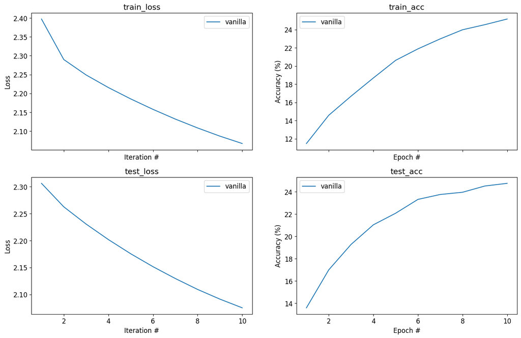

```python
fig_optim = None
fig_optim = train_with_optimizer('vanilla', optimizers.VanillaSGD, fig_optim)
```

## Momentum

The simple vanilla SGD update is rarely used in practice since it's very slow to converge relative to other optimization algorithms.

One reason is that naïvely updating in the direction of the current gradient causes it to fluctuate wildly in areas of the loss surface where some dimensions are much steeper than others. Another reason is that using the same learning rate for all parameters is not a great idea since not all parameters are created equal. For example, parameters associated with rare features should be updated with a larger step than ones associated with commonly-occurring features because they'll get less updates through the gradients.

Therefore more advanced optimizers take into account the previous gradients of a parameter and/or try to use a per-parameter specific learning rate instead of a common one.

Let's now implement a simple and common optimizer: SGD with Momentum. This optimizer takes **previous gradients** of a parameter into account when updating it's value instead of just the current one. In practice it usually provides faster convergence than the vanilla SGD.

The SGD with Momentum update rule can be stated as follows: $$\begin{align} \vec{v}_{t+1} &= \mu \vec{v}_t - \eta \delta \vec{\theta}_t \\ \vec{\theta}_{t+1} &= \vec{\theta}_t + \vec{v}_{t+1} \end{align}$$

Where $\eta$ is the learning rate, $\vec{\theta}$ is a model parameter, $\delta \vec{\theta}_t=\pderiv{L}{\vec{\theta}}(\vec{\theta}_t)$ is the gradient of the loss w.r.t. to the parameter and $\mu$ is a hyperparameter known as momentum.

Expanding the update rule recursively shows us now the parameter update infact depends on all previous gradient values for that parameter, where the old gradients are exponentially decayed by a factor of $\mu$ at each timestep.

Since we're incorporating previous gradient (update directions), a noisy value of the current gradient will have less effect so that the general direction of previous updates is maintained somewhat. The following figure illustrates this.

[figure not shown]

**TODO**:

1. Complete the implementation of the `MomentumSGD` class in the `hw2/optimizers.py` module.
2. Tweak the learning rate for momentum in `part2_optim_hp()` the function in the `hw2/answers.py` module.
3. Run the following block to compare to the vanilla SGD.

```
--- EPOCH 1/10 ---
train_batch (Avg. Loss 2.251, Accuracy 16.7): 100%|██████████| 100/100 [00:01<00:00, 79.50it/s]
test_batch (Avg. Loss 2.124, Accuracy 23.0): 100%|██████████| 100/100 [00:00<00:00, 237.48it/s]
--- EPOCH 2/10 ---
train_batch (Avg. Loss 2.058, Accuracy 24.4): 100%|██████████| 100/100 [00:01<00:00, 78.05it/s]
test_batch (Avg. Loss 2.021, Accuracy 25.3): 100%|██████████| 100/100 [00:00<00:00, 236.59it/s]
--- EPOCH 3/10 ---
train_batch (Avg. Loss 1.982, Accuracy 26.4): 100%|██████████| 100/100 [00:01<00:00, 81.10it/s]
test_batch (Avg. Loss 1.964, Accuracy 28.2): 100%|██████████| 100/100 [00:00<00:00, 238.89it/s]
--- EPOCH 4/10 ---
train_batch (Avg. Loss 1.929, Accuracy 28.6): 100%|██████████| 100/100 [00:01<00:00, 80.31it/s]
test_batch (Avg. Loss 1.928, Accuracy 31.0): 100%|██████████| 100/100 [00:00<00:00, 227.25it/s]
--- EPOCH 5/10 ---
train_batch (Avg. Loss 1.891, Accuracy 30.4): 100%|██████████| 100/100 [00:01<00:00, 76.27it/s]
test_batch (Avg. Loss 1.908, Accuracy 32.0): 100%|██████████| 100/100 [00:00<00:00, 244.29it/s]
--- EPOCH 6/10 ---
train_batch (Avg. Loss 1.861, Accuracy 32.6): 100%|██████████| 100/100 [00:01<00:00, 76.29it/s]
test_batch (Avg. Loss 1.890, Accuracy 32.6): 100%|██████████| 100/100 [00:00<00:00, 235.78it/s]
--- EPOCH 7/10 ---
train_batch (Avg. Loss 1.833, Accuracy 33.6): 100%|██████████| 100/100 [00:01<00:00, 82.18it/s]
test_batch (Avg. Loss 1.870, Accuracy 33.2): 100%|██████████| 100/100 [00:00<00:00, 238.09it/s]
--- EPOCH 8/10 ---
train_batch (Avg. Loss 1.806, Accuracy 35.1): 100%|██████████| 100/100 [00:01<00:00, 79.84it/s]
test_batch (Avg. Loss 1.856, Accuracy 33.9): 100%|██████████| 100/100 [00:00<00:00, 236.09it/s]
--- EPOCH 9/10 ---
train_batch (Avg. Loss 1.782, Accuracy 36.1): 100%|██████████| 100/100 [00:01<00:00, 80.47it/s]
test_batch (Avg. Loss 1.842, Accuracy 34.5): 100%|██████████| 100/100 [00:00<00:00, 241.58it/s]
--- EPOCH 10/10 ---
train_batch (Avg. Loss 1.760, Accuracy 37.0): 100%|██████████| 100/100 [00:01<00:00, 81.22it/s]
test_batch (Avg. Loss 1.831, Accuracy 35.3): 100%|██████████| 100/100 [00:00<00:00, 237.55it/s]
```

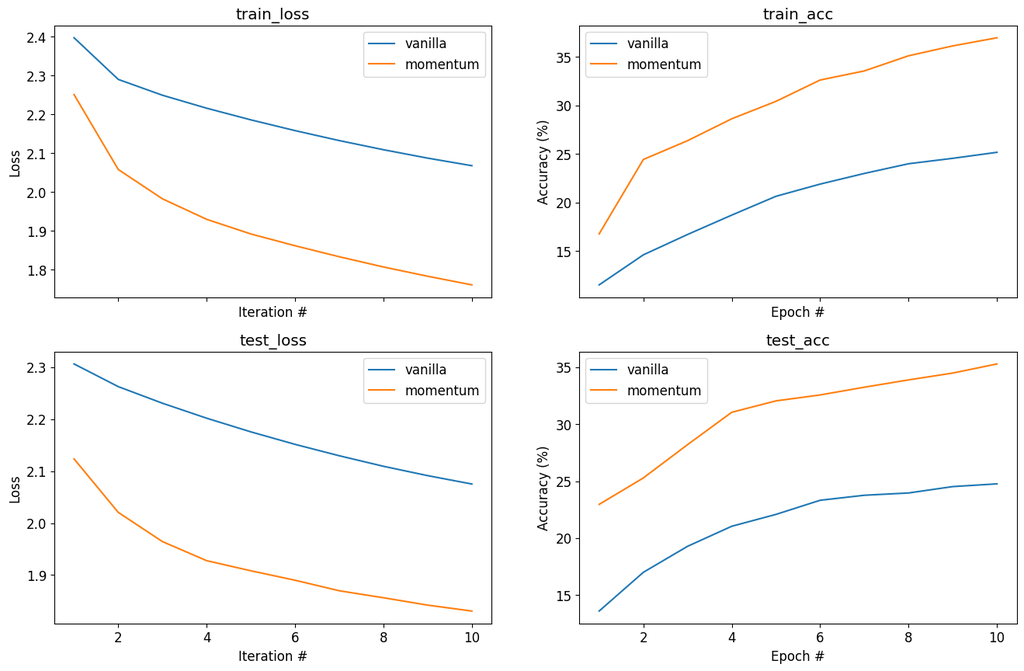

```python
fig_optim = train_with_optimizer('momentum', optimizers.MomentumSGD, fig_optim)
fig_optim
```

## RMSProp

This is another optmizer that accounts for previous gradients, but this time it uses them to adapt the learning rate per parameter.

RMSProp maintains a decaying moving average of previous squared gradients, $$ \vec{r}_{t+1} = \gamma\vec{r}_{t} + (1-\gamma)\delta\vec{\theta}_t^2 $$

where $0<\gamma<1$ is a decay constant usually set close to $1$. The update rule for each parameter is then, $$ \vec{\theta}_{t+1} = \vec{\theta}_t - \left( \frac{\eta}{\sqrt{r_{t+1}+\varepsilon}} \right) \delta\vec{\theta}_t $$

where $\varepsilon$ is a small constant to prevent numerical instability. The idea here is to decrease the learning rate for parameters with high gradient values and vice-versa. The decaying moving average prevents accumulating all the past gradients which would cause the effective learning rate to become zero.

**TODO**:

1. Complete the implementation of the `RMSProp` class in the `hw2/optimizers.py` module.
2. Tweak the learning rate for RMSProp in `part2_optim_hp()` the function in the `hw2/answers.py` module.
3. Run the following block to compare to the other optimizers.

```
--- EPOCH 1/10 ---
train_batch (Avg. Loss 2.337, Accuracy 16.7): 100%|██████████| 100/100 [00:01<00:00, 56.06it/s]
test_batch (Avg. Loss 2.087, Accuracy 21.6): 100%|██████████| 100/100 [00:00<00:00, 240.59it/s]
--- EPOCH 2/10 ---
train_batch (Avg. Loss 2.048, Accuracy 23.8): 100%|██████████| 100/100 [00:01<00:00, 55.72it/s]
test_batch (Avg. Loss 1.997, Accuracy 26.6): 100%|██████████| 100/100 [00:00<00:00, 236.73it/s]
--- EPOCH 3/10 ---
train_batch (Avg. Loss 1.953, Accuracy 27.8): 100%|██████████| 100/100 [00:01<00:00, 56.68it/s]
test_batch (Avg. Loss 1.946, Accuracy 28.6): 100%|██████████| 100/100 [00:00<00:00, 235.64it/s]
--- EPOCH 4/10 ---
train_batch (Avg. Loss 1.884, Accuracy 30.7): 100%|██████████| 100/100 [00:01<00:00, 55.95it/s]
test_batch (Avg. Loss 1.930, Accuracy 29.6): 100%|██████████| 100/100 [00:00<00:00, 238.69it/s]
--- EPOCH 5/10 ---
train_batch (Avg. Loss 1.841, Accuracy 32.5): 100%|██████████| 100/100 [00:01<00:00, 57.02it/s]
test_batch (Avg. Loss 1.915, Accuracy 29.8): 100%|██████████| 100/100 [00:00<00:00, 239.84it/s]
--- EPOCH 6/10 ---
train_batch (Avg. Loss 1.802, Accuracy 34.1): 100%|██████████| 100/100 [00:01<00:00, 56.40it/s]
test_batch (Avg. Loss 1.945, Accuracy 30.4): 100%|██████████| 100/100 [00:00<00:00, 237.82it/s]
--- EPOCH 7/10 ---
train_batch (Avg. Loss 1.772, Accuracy 35.4): 100%|██████████| 100/100 [00:01<00:00, 56.53it/s]
test_batch (Avg. Loss 1.875, Accuracy 32.7): 100%|██████████| 100/100 [00:00<00:00, 209.45it/s]
--- EPOCH 8/10 ---
train_batch (Avg. Loss 1.734, Accuracy 37.0): 100%|██████████| 100/100 [00:01<00:00, 54.37it/s]
test_batch (Avg. Loss 1.863, Accuracy 33.7): 100%|██████████| 100/100 [00:00<00:00, 244.74it/s]
--- EPOCH 9/10 ---
train_batch (Avg. Loss 1.709, Accuracy 37.5): 100%|██████████| 100/100 [00:01<00:00, 56.76it/s]
test_batch (Avg. Loss 1.808, Accuracy 36.0): 100%|██████████| 100/100 [00:00<00:00, 230.65it/s]
--- EPOCH 10/10 ---
train_batch (Avg. Loss 1.674, Accuracy 39.4): 100%|██████████| 100/100 [00:01<00:00, 55.92it/s]
test_batch (Avg. Loss 1.821, Accuracy 35.3): 100%|██████████| 100/100 [00:00<00:00, 239.44it/s]
```

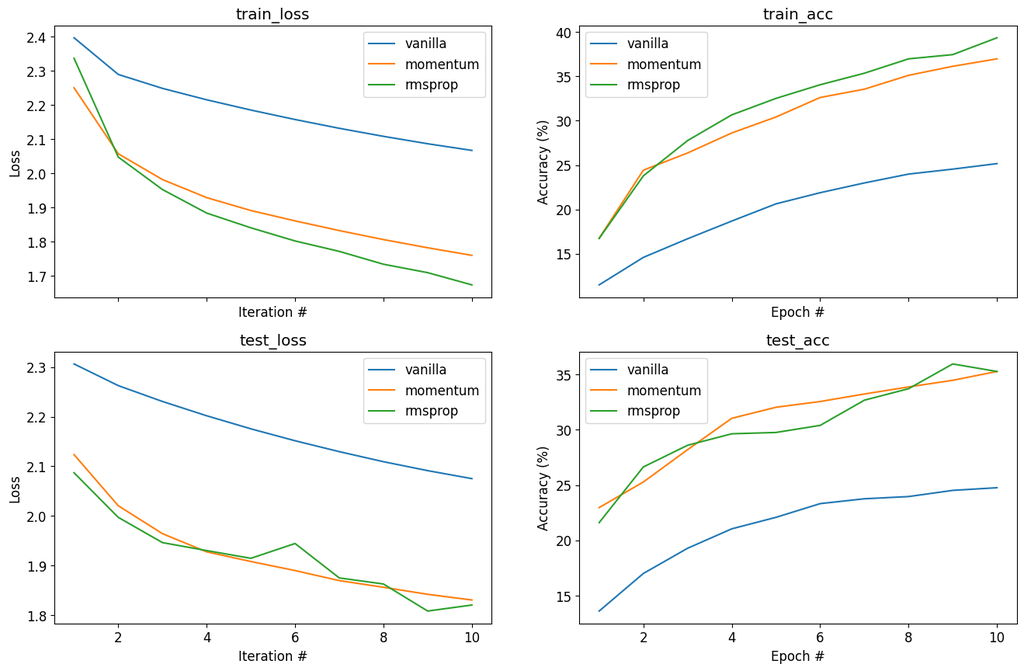

```python
fig_optim = train_with_optimizer('rmsprop', optimizers.RMSProp, fig_optim)
fig_optim
```

Note that you should get better train/test accuracy with Momentum and RMSProp than Vanilla.

## Dropout Regularization

[Dropout](http://jmlr.org/papers/volume15/srivastava14a.old/srivastava14a.pdf) is a useful technique to improve generalization of deep models.

The idea is simple: during the forward pass drop, i.e. set to to zero, the activation of each neuron, with a probability of $p$. For example, if $p=0.5$ this means we drop half the activations on average.

There are a few important things to note about dropout:

1. It is only performed during training. When testing our model the dropout layers should be a no-op.
2. In the backward pass, gradients are only propagated back into neurons that weren't dropped during the forward pass.
3. During testing, the activations must be scaled since the expected value of each neuron during the training phase is now $1-p$ times it's original expectation. Thus, we need to scale the test-time activations by $1-p$ to match. Equivalently, we can scale the train time activations by $1/(1-p)$.

**TODO**: Complete the implementation of the `Dropout` class in the `hw2/blocks.py` module.

```python
from hw2.grad_compare import compare_block_to_torch

# Check architecture of MLP with dropout layers
mlp_dropout = models.MLP(in_features, num_classes, [50]*3, dropout=0.6)
print(mlp_dropout)
test.assertEqual(len(mlp_dropout.sequence), 10)
for b1, b2 in zip(mlp_dropout.sequence, mlp_dropout.sequence[1:]):
    if str(b1) == 'relu':
        test.assertTrue(str(b2).startswith('Dropout'))
test.assertTrue(str(mlp_dropout.sequence[-1]).startswith('Linear'))

# Test end-to-end gradient in train and test modes.
mlp_dropout.train(True)
for diff in compare_block_to_torch(mlp_dropout, torch.randn(500, in_features)):
    test.assertLess(diff, 1e-2)

mlp_dropout.train(False)
for diff in compare_block_to_torch(mlp_dropout, torch.randn(500, in_features)):
    test.assertLess(diff, 1e-2)
```

```
MLP, Sequential
	[0] Linear(3072, 50)
	[1] ReLU
	[2] Dropout(p=0.6)
	[3] Linear(50, 50)
	[4] ReLU
	[5] Dropout(p=0.6)
	[6] Linear(50, 50)
	[7] ReLU
	[8] Dropout(p=0.6)
	[9] Linear(50, 10)

Comparing gradients...
input    diff=0.000
param#01 diff=0.000
param#02 diff=0.000
param#03 diff=0.000
param#04 diff=0.000
param#05 diff=0.000
param#06 diff=0.000
param#07 diff=0.000
param#08 diff=0.000
Comparing gradients...
input    diff=0.000
param#01 diff=0.000
param#02 diff=0.000
param#03 diff=0.000
param#04 diff=0.000
param#05 diff=0.000
param#06 diff=0.000
param#07 diff=0.000
param#08 diff=0.000
```

To see whether dropout really improves generalization, let's take a small training set (small enough to overfit) and a large test set and check whether we get less overfitting and perhaps improved test-set accuracy when using dropout.

```python
# Define a small set from CIFAR-10, but take a larger test set since we want to test generalization
batch_size = 10
max_batches = 40
in_features = 3*32*32
num_classes = 10
dl_train = torch.utils.data.DataLoader(ds_train, batch_size, shuffle=False)
dl_test = torch.utils.data.DataLoader(ds_test, batch_size*2, shuffle=False)
```

**TODO**: Tweak the hyperparameters for this section in the `part2_dropout_hp()` function in the `hw2/answers.py` module. Try to set them so that the first model (with `dropout`=0) overfits. You can disable the other dropout options until you tune the hyperparameters. We can then see the effect of dropout for generalization.

```python
# Get hyperparameters
hp = answers.part2_dropout_hp()
hidden_features = [400] * 1
num_epochs = 30
```

```
*** Training with dropout= 0
--- EPOCH 1/30 ---
train_batch (Avg. Loss 3.894, Accuracy 10.2): 100%|██████████| 40/40 [00:00<00:00, 76.66it/s]
test_batch (Avg. Loss 3.204, Accuracy 9.8): 100%|██████████| 40/40 [00:00<00:00, 254.15it/s]
train_batch (Avg. Loss 2.916, Accuracy 12.5): 100%|██████████| 40/40 [00:00<00:00, 64.27it/s]
test_batch (Avg. Loss 3.005, Accuracy 12.2): 100%|██████████| 40/40 [00:00<00:00, 221.68it/s]
train_batch (Avg. Loss 2.692, Accuracy 16.8): 100%|██████████| 40/40 [00:00<00:00, 75.14it/s]
test_batch (Avg. Loss 2.837, Accuracy 13.8): 100%|██████████| 40/40 [00:00<00:00, 233.83it/s]
train_batch (Avg. Loss 2.516, Accuracy 19.5): 100%|██████████| 40/40 [00:00<00:00, 76.63it/s]
test_batch (Avg. Loss 2.739, Accuracy 14.9): 100%|██████████| 40/40 [00:00<00:00, 241.27it/s]
train_batch (Avg. Loss 2.390, Accuracy 21.2): 100%|██████████| 40/40 [00:00<00:00, 75.85it/s]
test_batch (Avg. Loss 2.668, Accuracy 15.5): 100%|██████████| 40/40 [00:00<00:00, 227.61it/s]
train_batch (Avg. Loss 2.292, Accuracy 23.5): 100%|██████████| 40/40 [00:00<00:00, 77.31it/s]
test_batch (Avg. Loss 2.620, Accuracy 16.9): 100%|██████████| 40/40 [00:00<00:00, 237.55it/s]
--- EPOCH 7/30 ---
train_batch (Avg. Loss 2.215, Accuracy 26.8): 100%|██████████| 40/40 [00:00<00:00, 75.50it/s]
test_batch (Avg. Loss 2.583, Accuracy 17.9): 100%|██████████| 40/40 [00:00<00:00, 225.09it/s]
train_batch (Avg. Loss 2.150, Accuracy 27.8): 100%|██████████| 40/40 [00:00<00:00, 75.98it/s]
test_batch (Avg. Loss 2.556, Accuracy 18.4): 100%|██████████| 40/40 [00:00<00:00, 235.60it/s]
train_batch (Avg. Loss 2.093, Accuracy 29.2): 100%|██████████| 40/40 [00:00<00:00, 76.14it/s]
test_batch (Avg. Loss 2.534, Accuracy 19.2): 100%|██████████| 40/40 [00:00<00:00, 241.31it/s]
train_batch (Avg. Loss 2.043, Accuracy 31.5): 100%|██████████| 40/40 [00:00<00:00, 75.61it/s]
test_batch (Avg. Loss 2.515, Accuracy 20.2): 100%|██████████| 40/40 [00:00<00:00, 235.02it/s]
train_batch (Avg. Loss 1.996, Accuracy 32.8): 100%|██████████| 40/40 [00:00<00:00, 74.56it/s]
test_batch (Avg. Loss 2.499, Accuracy 20.6): 100%|██████████| 40/40 [00:00<00:00, 239.98it/s]
train_batch (Avg. Loss 1.954, Accuracy 34.5): 100%|██████████| 40/40 [00:00<00:00, 76.25it/s]
test_batch (Avg. Loss 2.487, Accuracy 21.4): 100%|██████████| 40/40 [00:00<00:00, 233.69it/s]
--- EPOCH 13/30 ---
train_batch (Avg. Loss 1.915, Accuracy 35.5): 100%|██████████| 40/40 [00:00<00:00, 76.23it/s]
test_batch (Avg. Loss 2.475, Accuracy 21.5): 100%|██████████| 40/40 [00:00<00:00, 225.01it/s]
train_batch (Avg. Loss 1.878, Accuracy 35.5): 100%|██████████| 40/40 [00:00<00:00, 74.81it/s]
test_batch (Avg. Loss 2.466, Accuracy 21.5): 100%|██████████| 40/40 [00:00<00:00, 237.49it/s]
train_batch (Avg. Loss 1.844, Accuracy 36.0): 100%|██████████| 40/40 [00:00<00:00, 75.25it/s]
test_batch (Avg. Loss 2.458, Accuracy 21.1): 100%|██████████| 40/40 [00:00<00:00, 239.69it/s]
train_batch (Avg. Loss 1.812, Accuracy 38.2): 100%|██████████| 40/40 [00:00<00:00, 76.21it/s]
test_batch (Avg. Loss 2.450, Accuracy 21.5): 100%|██████████| 40/40 [00:00<00:00, 244.47it/s]
train_batch (Avg. Loss 1.781, Accuracy 39.0): 100%|██████████| 40/40 [00:00<00:00, 74.84it/s]
test_batch (Avg. Loss 2.443, Accuracy 22.4): 100%|██████████| 40/40 [00:00<00:00, 238.92it/s]
train_batch (Avg. Loss 1.752, Accuracy 40.0): 100%|██████████| 40/40 [00:00<00:00, 75.72it/s]
test_batch (Avg. Loss 2.436, Accuracy 22.8): 100%|██████████| 40/40 [00:00<00:00, 233.95it/s]
```

[output cut: 146 more lines]

```
test_batch (Avg. Loss 2.238, Accuracy 20.1): 100%|██████████| 40/40 [00:00<00:00, 204.03it/s]
--- EPOCH 25/30 ---
train_batch (Avg. Loss 2.308, Accuracy 20.5): 100%|██████████| 40/40 [00:00<00:00, 70.25it/s]
test_batch (Avg. Loss 2.233, Accuracy 20.1): 100%|██████████| 40/40 [00:00<00:00, 219.98it/s]
train_batch (Avg. Loss 2.274, Accuracy 19.5): 100%|██████████| 40/40 [00:00<00:00, 74.23it/s]
test_batch (Avg. Loss 2.228, Accuracy 20.9): 100%|██████████| 40/40 [00:00<00:00, 234.74it/s]
train_batch (Avg. Loss 2.252, Accuracy 20.5): 100%|██████████| 40/40 [00:00<00:00, 76.33it/s]
test_batch (Avg. Loss 2.228, Accuracy 20.2): 100%|██████████| 40/40 [00:00<00:00, 243.91it/s]
train_batch (Avg. Loss 2.276, Accuracy 20.5): 100%|██████████| 40/40 [00:00<00:00, 74.73it/s]
test_batch (Avg. Loss 2.226, Accuracy 20.0): 100%|██████████| 40/40 [00:00<00:00, 234.23it/s]
train_batch (Avg. Loss 2.263, Accuracy 18.2): 100%|██████████| 40/40 [00:00<00:00, 74.49it/s]
test_batch (Avg. Loss 2.224, Accuracy 20.6): 100%|██████████| 40/40 [00:00<00:00, 225.40it/s]
--- EPOCH 30/30 ---
train_batch (Avg. Loss 2.269, Accuracy 21.0): 100%|██████████| 40/40 [00:00<00:00, 75.25it/s]
test_batch (Avg. Loss 2.219, Accuracy 21.2): 100%|██████████| 40/40 [00:00<00:00, 234.50it/s]
```

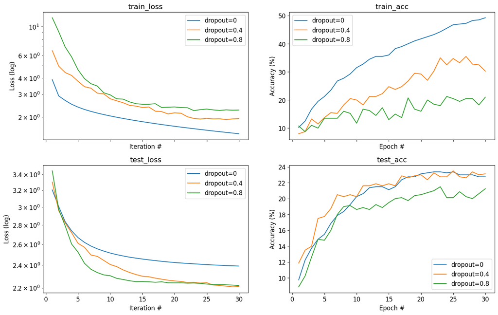

```python
torch.manual_seed(seed)
fig=None
for dropout in [0, 0.4, 0.8]:
#for dropout in [0]:
    model = models.MLP(in_features, num_classes, hidden_features, wstd=hp['wstd'], dropout=dropout)
    loss_fn = blocks.CrossEntropyLoss()
    optimizer = optimizers.MomentumSGD(model.params(), learn_rate=hp['lr'], reg=0)

    print('*** Training with dropout=', dropout)
    trainer = training.BlocksTrainer(model, loss_fn, optimizer)
    fit_res_dropout = trainer.fit(dl_train, dl_test, num_epochs, max_batches=max_batches, print_every=6)
    fig, axes = plot_fit(fit_res_dropout, fig=fig, legend=f'dropout={dropout}', log_loss=True)
```

## Questions

**TODO** Answer the following questions. Write your answers in the appropriate variables in the module `hw2/answers.py`.

```python
from helpers.answers import display_answer
import hw2.answers
```

### Question 1

Regarding the graphs you got for the three dropout configurations:

1. Explain the graphs of no-dropout vs dropout. Do they match what you expected to see?
   - If yes, explain why and provide examples based on the graphs.
   - If no, explain what you think the problem is and what should be modified to fix it.
2. Compare the low-dropout setting to the high-dropout setting and explain based on your graphs.

```python
display_answer(hw2.answers.part2_q1)
```

1. The results we got are in line with what we expected.

It can be seen that the order of the loss values decreases as the dropout intensity is reduced (both in train and in test). In the same way, the order of the accuracy values increases. It can be seen that for a dropout value of 0.4, results closer to the model without dropout were obtained for the test set, which means that the generalization ability was good. For a dropout value of 0.8 the regularization was too strong and harmed the model's ability to learn and generalize.  
2. As we wrote in the previous question, dropout with a probability of 0.8 damaged the model's ability to learn and generalize and this can also be seen in the high loss value in the test set (compared to values of 0 and 0.4). Similarly, the accuracy is almost 10% lower compared to the other 2 models.

### Question 2

When training a model with the cross-entropy loss function, is it possible for the test loss to **increase** for a few epochs while the test accuracy also **increases**?

If it's possible explain how, if it's not explain why not.

```python
display_answer(hw2.answers.part2_q2)
```

Yes, it is possible that the test loss and test accuracy values will both increase because these two measurements do not measure the same thing. While Accuracy measures the proportion of correct (discrete) predictions, the CE loss measures the "magnitude" of the error expressed in the log "distance" for the correct label (continuous since the log function is continuous). If so, there may be situations in which it will be possible to increase the model error (by reducing the score of the correct label for a certain sample) but still keep the sample correctly classified (the score will still be the highest) and on the other hand another sample that was on the threshold and was not classified correct, will get a higher score which will change its classification to the correct one and thus the accuracy alongside the loss which can increase as well.

$$ \newcommand{\mat}[1]{\boldsymbol {#1}} \newcommand{\mattr}[1]{\boldsymbol {#1}^\top} \newcommand{\matinv}[1]{\boldsymbol {#1}^{-1}} \newcommand{\vec}[1]{\boldsymbol {#1}} \newcommand{\vectr}[1]{\boldsymbol {#1}^\top} \newcommand{\rvar}[1]{\mathrm {#1}} \newcommand{\rvec}[1]{\boldsymbol{\mathrm{#1}}} \newcommand{\diag}{\mathop{\mathrm {diag}}} \newcommand{\set}[1]{\mathbb {#1}} \newcommand{\norm}[1]{\left\lVert#1\right\rVert} \newcommand{\pderiv}[2]{\frac{\partial #1}{\partial #2}} \newcommand{\bb}[1]{\boldsymbol{#1}} $$

# Part 3: Convolutional Architectures

In this part we will explore convolution networks and the effects of their architecture on accuracy. We'll implement a common block-based deep CNN pattern and we'll perform various experiments on it while varying the architecture. Then we'll implement our own custom architecture to see whether we can get high classification results on a large subset of CIFAR-10.

Training will be performed on GPU.

```python
import os
import re
import sys
import glob
import numpy as np
import matplotlib.pyplot as plt
import unittest
import torch
import torchvision
import torchvision.transforms as tvtf

%matplotlib inline
%load_ext autoreload
%autoreload 2

seed = 42

plt.rcParams.update({'font.size': 12})
test = unittest.TestCase()
```

```python
device = torch.device('cuda' if torch.cuda.is_available() else 'cpu')
```

```python
# Verify pytorch is using CUDA
print(device)
```

```
cpu
```

## Convolutional layers and networks

Convolutional layers are the most essential building blocks of the state of the art deep learning image classification models and also play an important role in many other tasks. As we saw in the tutorial, convolutional layers operate on and produce volumes (3D tensors) of activations.

One way to think about them is as if the neurons are organized in a 3D grid, where neurons at the same depth share weights (represented here as colors). Contrary to fully connected (affine) layers, neurons in convolutional layers are **not** connected to each of the activations of the previous layer. Instead, each neuron is connected only to a small region of the input volume e.g. a 5x5x$C_{\mathrm{in}}$ slice (where $C_{\mathrm{in}}$ is the input volume's depth).

[figure not shown]

Another way to interpret convolutional layers is as a collection of 3D learnable filters, each of which operates on a small spatial region of the input volume. Each filter is convolved with the input volume ("slides over it"), and a dot product is computed at each location followed by a non-linearity which produces one activation. All these activations produce a 2D plane known as a **feature map**. Multiple feature maps (one for each filter) comprise the output volume.

[figure not shown]

A crucial property of convolutional layers is their translation invariance, i.e. their ability to detect features regardelss of their spatial location in the input.

Convolutional network architectures usually follow a pattern basic repeating blocks: one or more convolution layers, each followed by a non-linearity (generally ReLU) and then a pooling layer to reduce spatial dimensions. Usually, the number of convolutional filters increases the deeper they are in the network. These layers are meant to extract features from the input. Then, one or more fully-connected layers is used to combine the extracted features into the required number of output class scores.

## Building convolutional networks with PyTorch

PyTorch provides all the basic building blocks needed for creating a convolutional arcitecture within the [`torch.nn`](https://pytorch.org/docs/stable/nn.html) package. Let's use them to create a basic convolutional network with the following architecture pattern:

```
[(CONV -> ReLU)*P -> MaxPool]*(N/P) -> (Linear -> ReLU)*M -> Linear
```

Here $N$ is the total number of convolutional layers, $P$ specifies how many convolutions to perform before each pooling layer and $M$ specifies the number of hidden fully-connected layers before the final output layer.

**TODO**: Complete the implementaion of the `ConvClassifier` class in the `hw2/models.py` module.

```python
import hw2.models as models
torch.manual_seed(seed)

net = models.ConvClassifier((3,100,100), 10, filters=[32]*4, pool_every=2, hidden_dims=[100]*2).to(device)
print(net)

test_image = torch.randint(low=0, high=256, size=(3, 100, 100), dtype=torch.float).to(device)
test_out = net(test_image.unsqueeze(0))
print('out =', test_out)

expected_out = torch.load('tests/assets/expected_conv_out.pt').to(device)
test.assertLess(torch.norm(test_out - expected_out).item(), 1e-5)
```

```
ConvClassifier(
  (feature_extractor): Sequential(
    (0): Conv2d(3, 32, kernel_size=(3, 3), stride=(1, 1), padding=(1, 1))
    (1): ReLU(inplace=True)
    (2): Conv2d(32, 32, kernel_size=(3, 3), stride=(1, 1), padding=(1, 1))
    (3): ReLU(inplace=True)
    (4): MaxPool2d(kernel_size=(2, 2), stride=(2, 2), padding=(0, 0), dilation=1, ceil_mode=False)
    (5): Conv2d(32, 32, kernel_size=(3, 3), stride=(1, 1), padding=(1, 1))
    (6): ReLU(inplace=True)
    (7): Conv2d(32, 32, kernel_size=(3, 3), stride=(1, 1), padding=(1, 1))
    (8): ReLU(inplace=True)
    (9): MaxPool2d(kernel_size=(2, 2), stride=(2, 2), padding=(0, 0), dilation=1, ceil_mode=False)
  )
  (classifier): Sequential(
    (0): Flatten(start_dim=1, end_dim=-1)
    (1): Linear(in_features=20000, out_features=100, bias=True)
    (2): ReLU(inplace=True)
    (3): Linear(in_features=100, out_features=100, bias=True)
    (4): ReLU(inplace=True)
    (5): Linear(in_features=100, out_features=10, bias=True)
  )
)
out = tensor([[-0.0868, -0.3790, -0.4341, -0.1236, -0.2160,  0.1683,  0.4739,  0.0750,
          0.1151, -0.1606]], grad_fn=<AddmmBackward>)
```

**Note about running on GPUs**.

Notice how we called `.to(device)` on **both** the model and the input tensor. Here the `device` is a `torch.device` object that we created above. If an nvidia GPU is available on the machine you're running this on, the `device` will be `'cuda'`. When you run `.to(device)` on a model, it recursively goes over all the model parameter tensors and copies their memory to the GPU. Similarly, calling `.to(device)` on the input image also copies it.

In order to train on a GPU, you need to make sure to move **all** your tensors to it. You'll get errors if you try to mix CPU and GPU tensors in a computation.

```python
print(f'This notebook is running with device={device}')
print(f'The model parameter tensors are therefore also on device={next(net.parameters()).device}')
print(f'The test image is therefore also on device={test_image.device}')
```

```
This notebook is running with device=cpu
The model parameter tensors are therefore also on device=cpu
The test image is therefore also on device=cpu
```

Let's load CIFAR-10 again to use as our dataset.

Note: If you enconter an [SSL: CERTIFICATE_VERIFY_FAILED], uncomment the below lines and run them.

```python
# import ssl
# ssl._create_default_https_context = ssl._create_unverified_context
```

```python
data_dir = os.path.join(os.getcwd(), '.pytorch-datasets')
ds_train = torchvision.datasets.CIFAR10(root=data_dir, download=True, train=True, transform=tvtf.ToTensor())
ds_test = torchvision.datasets.CIFAR10(root=data_dir, download=True, train=False, transform=tvtf.ToTensor())

print(f'Train: {len(ds_train)} samples')
print(f'Test: {len(ds_test)} samples')

x0,_ = ds_train[0]
in_size = x0.shape
num_classes = 10
print('input image size =', in_size)
```

```
Files already downloaded and verified
Files already downloaded and verified
Train: 50000 samples
Test: 10000 samples
input image size = torch.Size([3, 32, 32])
```

Now as usual, as a sanity test let's make sure we can overfit a tiny dataset with our model. But first we need to adapt our `Trainer` for PyTorch models.

**TODO**: Complete the implementaion of the `TorchTrainer` class in the `hw2/training.py` module.

```python
import hw2.training as training
torch.manual_seed(seed)

# Define a tiny part of the CIFAR-10 dataset to overfit it
batch_size = 2
max_batches = 25
dl_train = torch.utils.data.DataLoader(ds_train, batch_size, shuffle=False)

# Create model, loss and optimizer instances
model = models.ConvClassifier(in_size, num_classes, filters=[32], pool_every=1, hidden_dims=[100])
loss_fn = torch.nn.CrossEntropyLoss()
optimizer = torch.optim.SGD(model.parameters(), lr=1e-2, momentum=0.9,)

# Use TorchTrainer to run only the training loop a few times.
trainer = training.TorchTrainer(model, loss_fn, optimizer, device)
best_acc = 0
for i in range(22):
    res = trainer.train_epoch(dl_train, max_batches=max_batches, verbose=(i%2==0))
    best_acc = res.accuracy if res.accuracy > best_acc else best_acc

# Test overfitting
test.assertGreaterEqual(best_acc, 95)
```

```
train_batch (Avg. Loss 2.371, Accuracy 6.0): 100%|██████████| 25/25 [00:00<00:00, 187.59it/s]
train_batch (Avg. Loss 2.238, Accuracy 16.0): 100%|██████████| 25/25 [00:00<00:00, 165.74it/s]
train_batch (Avg. Loss 2.131, Accuracy 22.0): 100%|██████████| 25/25 [00:00<00:00, 158.13it/s]
train_batch (Avg. Loss 1.829, Accuracy 34.0): 100%|██████████| 25/25 [00:00<00:00, 155.50it/s]
train_batch (Avg. Loss 1.058, Accuracy 58.0): 100%|██████████| 25/25 [00:00<00:00, 157.67it/s]
train_batch (Avg. Loss 0.992, Accuracy 66.0): 100%|██████████| 25/25 [00:00<00:00, 159.50it/s]
train_batch (Avg. Loss 0.762, Accuracy 68.0): 100%|██████████| 25/25 [00:00<00:00, 162.44it/s]
train_batch (Avg. Loss 0.596, Accuracy 76.0): 100%|██████████| 25/25 [00:00<00:00, 159.73it/s]
train_batch (Avg. Loss 0.560, Accuracy 86.0): 100%|██████████| 25/25 [00:00<00:00, 160.11it/s]
train_batch (Avg. Loss 0.298, Accuracy 90.0): 100%|██████████| 25/25 [00:00<00:00, 156.61it/s]
train_batch (Avg. Loss 0.160, Accuracy 94.0): 100%|██████████| 25/25 [00:00<00:00, 159.21it/s]
```

## Experimenting with model architectures

You will now perform a series of experiments that train various model configurations on a much larger part of the CIFAR-10 dataset.

To perform the experiments, you'll need to use a machine with a GPU since training time might be too long otherwise.

### General notes for running experiments

- You can run the experiments on a different machine and copy the results (files)

to the `results` folder on your local machine. This notebook will only display the results, not run the actual experiment code (except for a demo run).

- It's important to give each experiment run a name as specified by the notebook instructions later on. The each run has a `run_name` parameter that will also be the name of the results file which this notebook will expect to load.
- You will implement the code to run the experiments in the `hw2/experiments.py` module. This module has a CLI parser so that you can invoke it as a script and pass in all the configuration parameters for a single experiment run.
- You should use `python -m hw2.experiments run-exp` to run an experiment, and **not** `python hw2/experiments.py run-exp`, regardless of how/where you run it.

### Experiment 1 - Network depth and number of filters

In this part we will test some different architecture configurations based on our `ConvClassifier`. Specifically, we want to try different depths and number of features to see the effects these parameters have on the model's performance.

To do this, we'll define two extra hyperparameters for our model, `K` (`filters_per_layer`) and `L` (`layers_per_block`).

- `K` is a list, containing the number of filters we want to have in our conv layers.
- `L` is the number of consecutive layers with the same number of filters to use.

For example, if `K=[32, 64]` and `L=2` it means we want two conv layers with 32 filters followed by two conv layers with 64 filters. The feature-extraction part of our model will therefore be:

```
Conv(X,32)->ReLu->Conv(32,32)->ReLU->MaxPool->Conv(32,64)->ReLU->Conv(64,64)->ReLU->MaxPool
```

We'll try various values of the `K` and `L` parameters in combination and see how each architecture trains. **All other hyperparameters are up to you**, including the choice of the optimization algorithm, the learning rate, regularization and architecture hyperparams such as `pad_every` and `hidden_dims`. You can try some manual runs to determine some good values for the hyperparameters or implement cross-validation to do it. However, the **dataset size** you test on should be large. Use at least ~12000 training images and ~3000 validation images. The **batch size** parameter however is also up to you.

The important thing is that you state what you used, how you decided on it, and explain your results based on that.

First we need to write some code to run the experiment.

**TODO**:

1. Implement the `run_experiment()` function in the `hw2/experiments.py` module.
2. If you haven't done so already, it would be an excellent idea to implement the **early stopping** feature of the `Trainer` class.

The following block tests that your implementation works. It's also meant to show you that each experiment run creates a result file containing the parameters to reproduce and the `FitResult` object for plotting.

```
Files already downloaded and verified
Files already downloaded and verified
--- EPOCH 1/10 ---
train_batch (Avg. Loss 2.319, Accuracy 13.2): 100%|██████████| 10/10 [00:00<00:00, 37.57it/s]
test_batch (Avg. Loss 2.243, Accuracy 25.0): 100%|██████████| 10/10 [00:00<00:00, 200.47it/s]
train_batch (Avg. Loss 2.195, Accuracy 18.8): 100%|██████████| 10/10 [00:00<00:00, 32.08it/s]
test_batch (Avg. Loss 2.109, Accuracy 28.3): 100%|██████████| 10/10 [00:00<00:00, 198.03it/s]
train_batch (Avg. Loss 1.999, Accuracy 29.4): 100%|██████████| 10/10 [00:00<00:00, 30.09it/s]
test_batch (Avg. Loss 2.003, Accuracy 30.0): 100%|██████████| 10/10 [00:00<00:00, 183.32it/s]
train_batch (Avg. Loss 1.871, Accuracy 36.6): 100%|██████████| 10/10 [00:00<00:00, 29.22it/s]
test_batch (Avg. Loss 1.949, Accuracy 30.8): 100%|██████████| 10/10 [00:00<00:00, 179.11it/s]
train_batch (Avg. Loss 1.756, Accuracy 39.8): 100%|██████████| 10/10 [00:00<00:00, 29.69it/s]
test_batch (Avg. Loss 1.914, Accuracy 32.5): 100%|██████████| 10/10 [00:00<00:00, 180.76it/s]
train_batch (Avg. Loss 1.655, Accuracy 43.6): 100%|██████████| 10/10 [00:00<00:00, 29.19it/s]
test_batch (Avg. Loss 1.873, Accuracy 35.8): 100%|██████████| 10/10 [00:00<00:00, 173.23it/s]
train_batch (Avg. Loss 1.548, Accuracy 46.4): 100%|██████████| 10/10 [00:00<00:00, 29.83it/s]
test_batch (Avg. Loss 1.826, Accuracy 35.8): 100%|██████████| 10/10 [00:00<00:00, 172.17it/s]
train_batch (Avg. Loss 1.435, Accuracy 55.6): 100%|██████████| 10/10 [00:00<00:00, 30.20it/s]
test_batch (Avg. Loss 1.800, Accuracy 35.8): 100%|██████████| 10/10 [00:00<00:00, 183.36it/s]
train_batch (Avg. Loss 1.355, Accuracy 58.4): 100%|██████████| 10/10 [00:00<00:00, 29.17it/s]
test_batch (Avg. Loss 1.782, Accuracy 37.5): 100%|██████████| 10/10 [00:00<00:00, 164.95it/s]
--- EPOCH 10/10 ---
train_batch (Avg. Loss 1.279, Accuracy 60.4): 100%|██████████| 10/10 [00:00<00:00, 28.70it/s]
test_batch (Avg. Loss 1.771, Accuracy 37.5): 100%|██████████| 10/10 [00:00<00:00, 171.08it/s]
output  {'config': {'run_name': 'test_run', 'out_dir': './results', 'seed': 42, 'bs_train': 50, 'bs_test': 12, 'batches': 10, 'epochs': 10, 'early_stopping': 5, 'checkpoints': None, 'lr': 0.001, 'reg': 0.001, 'filters_per_layer': [32], 'pool_every': 1, 'hidden_dims': [100], 'ycn': False, 'kw': {}, '…
*** Output file ./results\test_run.json written
experiment config:  {'run_name': 'test_run', 'out_dir': './results', 'seed': 42, 'bs_train': 50, 'bs_test': 12, 'batches': 10, 'epochs': 10, 'early_stopping': 5, 'checkpoints': None, 'lr': 0.001, 'reg': 0.001, 'filters_per_layer': [32], 'pool_every': 1, 'hidden_dims': [100], 'ycn': False, 'kw': {}, …
```

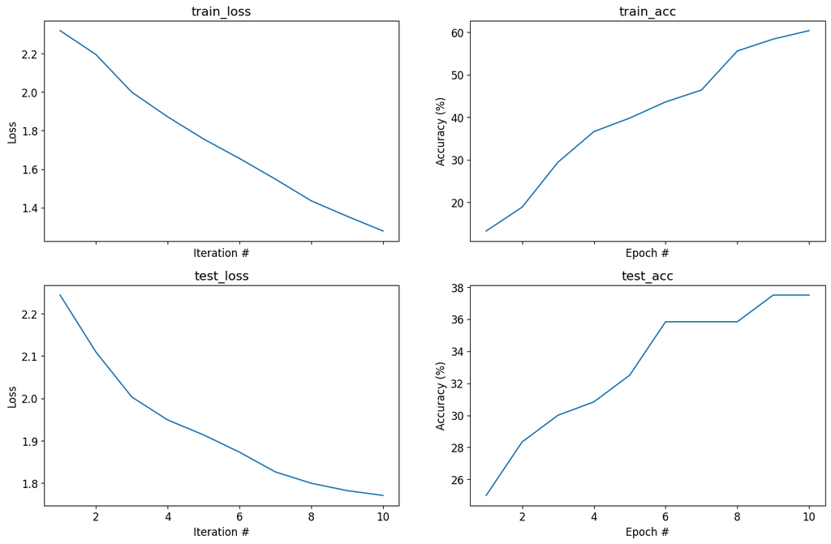

```python
import hw2.experiments as experiments
from hw2.experiments import load_experiment
from helpers.plot import plot_fit

# Test experiment1 implementation on a few data samples and with a small model
experiments.run_experiment('test_run', seed=seed, bs_train=50, batches=10, epochs=10, early_stopping=5,
                           filters_per_layer=[32], layers_per_block=1, pool_every=1, hidden_dims=[100])

# There should now be a file 'test_run.json' in your `results/` folder.
# We can use it to load the results of the experiment.
cfg, fit_res = load_experiment('results/test_run.json')
_, _ = plot_fit(fit_res)

# And `cfg` contains the exact parameters to reproduce it
print('experiment config: ', cfg)
```

We'll use the following function to load multiple experiment results and plot them together.

```python
def plot_exp_results(filename_pattern, results_dir='results'):
    fig = None
    result_files = glob.glob(os.path.join(results_dir, filename_pattern))
    result_files.sort()
    if len(result_files) == 0:
        print(f'No results found for pattern {filename_pattern}.', file=sys.stderr)
        return
    for filepath in result_files:
        m = re.match('exp\d_(\d_)?(.*)\.json', os.path.basename(filepath))
        cfg, fit_res = load_experiment(filepath)
        fig, axes = plot_fit(fit_res, fig, legend=m[2],log_loss=True)
    del cfg['filters_per_layer']
    del cfg['layers_per_block']
    print('common config: ', cfg)
```

#### Experiment 1.1: Varying the network depth (`L`)

First, we'll test the effect of the network depth on training.

**Configuratons**:

- `K=32` fixed, with `L=2,4,8,16` varying per run
- `K=64` fixed, with `L=2,4,8,16` varying per run

So 8 different runs in total.

**Naming runs**: Each run should be named `exp1_1_K{}_L{}` where the braces are placeholders for the values. For example, the first run should be named `exp1_1_K32_L2`.

**TODO**: Run the experiment on the above configuration. Make sure the result file names are as expected. Use the following blocks to display the results.

```
common config:  {'run_name': 'exp1_1_K32_L8', 'out_dir': './results', 'seed': 42, 'bs_train': 128, 'bs_test': 32, 'batches': 100, 'epochs': 10, 'early_stopping': 5, 'checkpoints': None, 'lr': 0.001, 'reg': 0.001, 'pool_every': 4, 'hidden_dims': [100, 100], 'ycn': False, 'kw': {}}
```

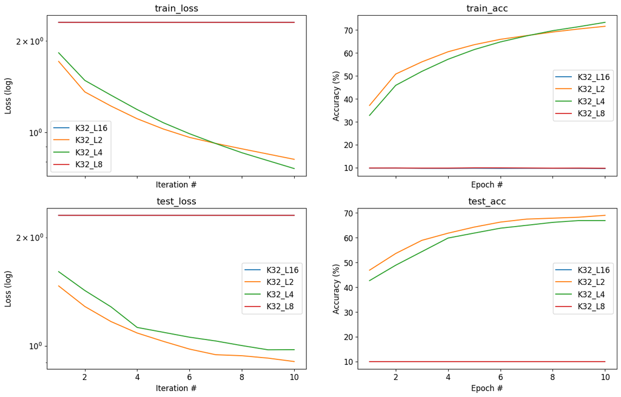

```python
plot_exp_results('exp1_1_K32*.json')
```

```
common config:  {'run_name': 'exp1_1_K64_L8', 'out_dir': './results', 'seed': 42, 'bs_train': 128, 'bs_test': 32, 'batches': 100, 'epochs': 10, 'early_stopping': 5, 'checkpoints': None, 'lr': 0.001, 'reg': 0.001, 'pool_every': 4, 'hidden_dims': [100, 100], 'ycn': False, 'kw': {}}
```

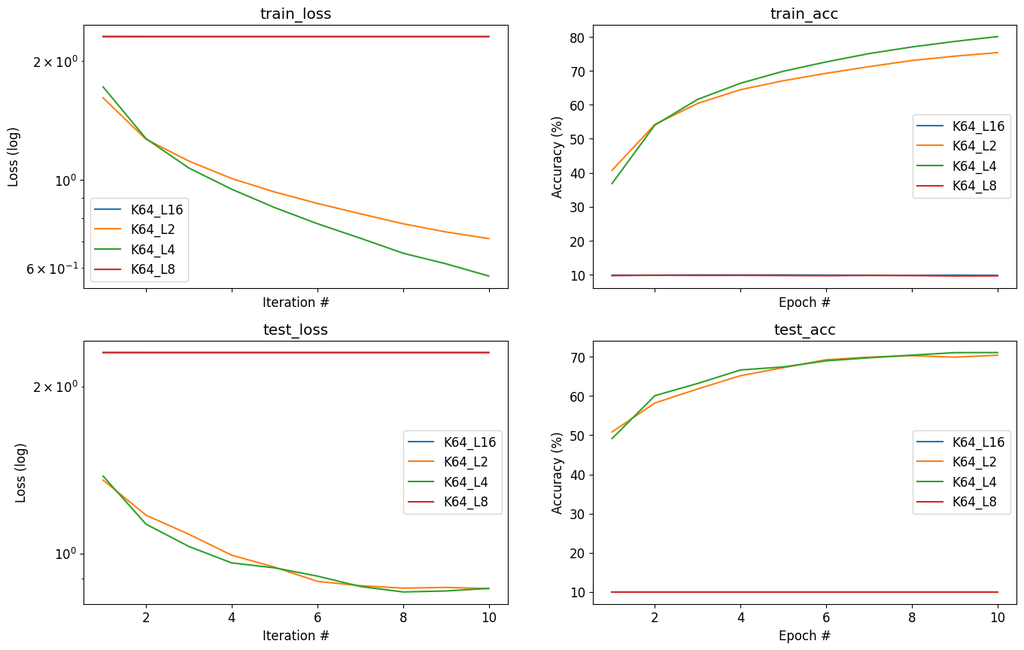

```python
plot_exp_results('exp1_1_K64*.json')
```

#### Experiment 1.2: Varying the number of filters per layer (`K`)

Now we'll test the effect of the number of convolutional filters in each layer.

**Configuratons**:

- `L=2` fixed, with `K=[32],[64],[128],[258]` varying per run.
- `L=4` fixed, with `K=[32],[64],[128],[258]` varying per run.
- `L=8` fixed, with `K=[32],[64],[128],[258]` varying per run.

So 12 different runs in total. To clarify, each run `K` takes the value of a list with a single element.

**Naming runs**: Each run should be named `exp1_2_L{}_K{}` where the braces are placeholders for the values. For example, the first run should be named `exp1_2_L2_K32`.

**TODO**: Run the experiment on the above configuration. Make sure the result file names are as expected. Use the following blocks to display the results.

```
common config:  {'run_name': 'exp1_2_L2_K64', 'out_dir': './results', 'seed': 42, 'bs_train': 128, 'bs_test': 32, 'batches': 100, 'epochs': 10, 'early_stopping': 5, 'checkpoints': None, 'lr': 0.001, 'reg': 0.001, 'pool_every': 2, 'hidden_dims': [100, 100], 'ycn': False, 'kw': {}}
```

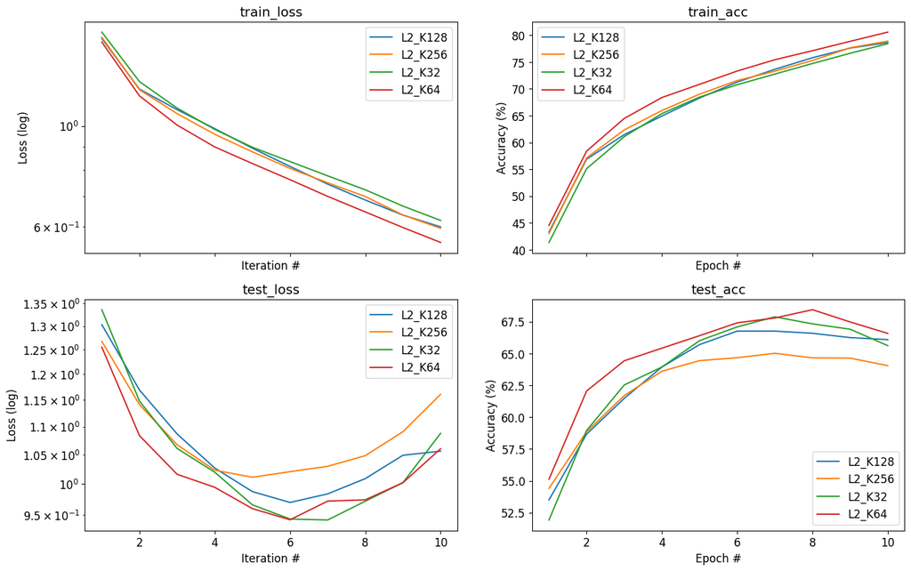

```python
plot_exp_results('exp1_2_L2*.json')
```

```
common config:  {'run_name': 'exp1_2_L4_K64', 'out_dir': './results', 'seed': 42, 'bs_train': 128, 'bs_test': 32, 'batches': 100, 'epochs': 10, 'early_stopping': 5, 'checkpoints': None, 'lr': 0.001, 'reg': 0.001, 'pool_every': 2, 'hidden_dims': [100, 100], 'ycn': False, 'kw': {}}
```

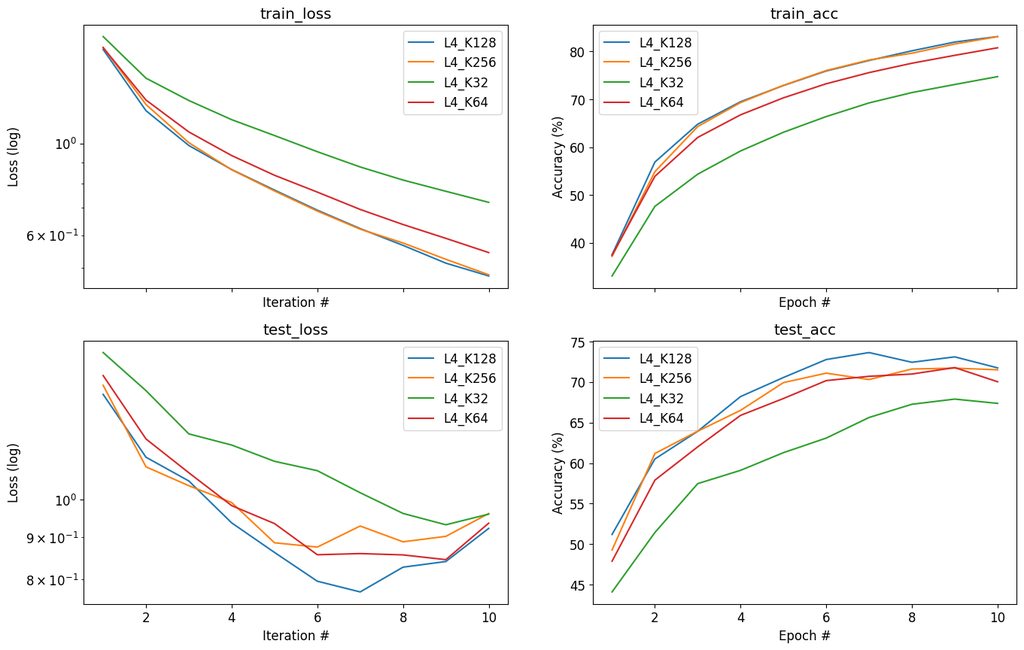

```python
plot_exp_results('exp1_2_L4*.json')
```

```
common config:  {'run_name': 'exp1_2_L8_K64', 'out_dir': './results', 'seed': 42, 'bs_train': 128, 'bs_test': 32, 'batches': 100, 'epochs': 10, 'early_stopping': 5, 'checkpoints': None, 'lr': 0.001, 'reg': 0.001, 'pool_every': 2, 'hidden_dims': [100, 100], 'ycn': False, 'kw': {}}
```

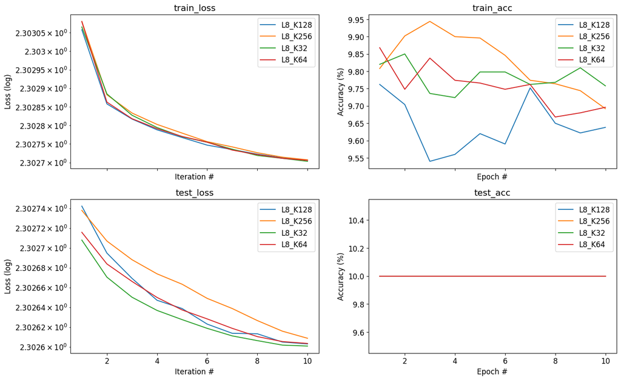

```python
plot_exp_results('exp1_2_L8*.json')
```

#### Experiment 1.3: Varying both the number of filters (`K`) and network depth (`L`)

Now we'll test the effect of the number of convolutional filters in each layer.

**Configuratons**:

- `K=[64, 128, 256]` fixed with `L=1,2,3,4` varying per run.

So 4 different runs in total. To clarify, each run `K` takes the value of an array with a three elements.

**Naming runs**: Each run should be named `exp1_3_L{}_K{}-{}-{}` where the braces are placeholders for the values. For example, the first run should be named `exp1_3_L1_K64-128-256`.

**TODO**: Run the experiment on the above configuration. Make sure the result file names are as expected. Use the following blocks to display the results.

```
common config:  {'run_name': 'exp1_3_L4_K64-128-256', 'out_dir': './results', 'seed': 42, 'bs_train': 128, 'bs_test': 32, 'batches': 100, 'epochs': 10, 'early_stopping': 5, 'checkpoints': None, 'lr': 0.001, 'reg': 0.001, 'pool_every': 4, 'hidden_dims': [100], 'ycn': False, 'kw': {}}
```

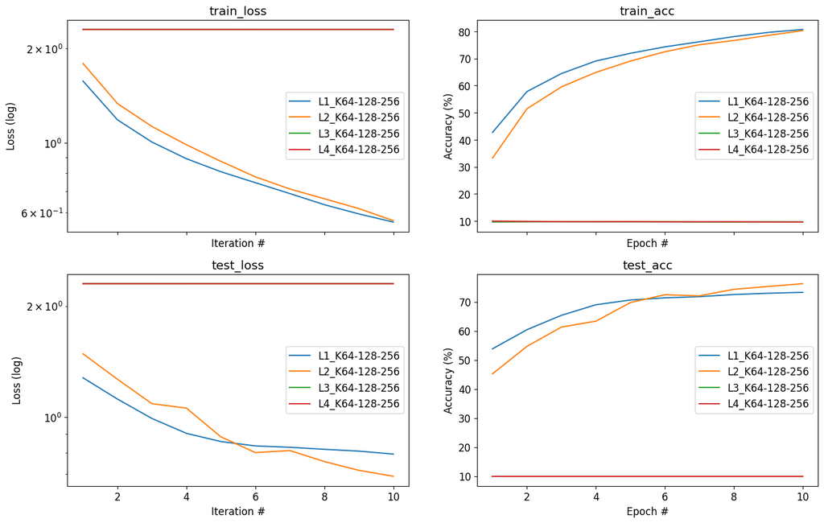

```python
plot_exp_results('exp1_3*.json')
```

### Experiment 2 - Custom network architecture

In this part you will create your own custom network architecture based on the `ConvClassifier` you've implemented.

Try to overcome some of the limitations your experiment 1 results, using what you learned in the course.

You are free to add whatever you like to the model, for instance

- Batch normalization
- Dropout layers
- Skip connections
- Change kernel spatial sizes and strides
- Custom blocks or ideas from known architectures (e.g. inception module)

Just make sure to keep the model's `init` API identical (or maybe just add parameters).

**TODO**: Implement your custom architecture in the `YourCodeNet` class within the `hw2/models.py` module.

```python
net = models.YourCodeNet((3,100,100), 10, filters=[32]*4, pool_every=2, hidden_dims=[100]*2).to(device)
print(net)

test_image = torch.randint(low=0, high=256, size=(3, 100, 100), dtype=torch.float).to(device)
test_out = net(test_image.unsqueeze(0))
print('out =', test_out)
```

```
YourCodeNet(
  (feature_extractor): Sequential(
    (0): Conv2d(3, 32, kernel_size=(3, 3), stride=(1, 1), padding=(1, 1))
    (1): ReLU(inplace=True)
    (2): Dropout(p=0.3, inplace=False)
    (3): BatchNorm2d(32, eps=1e-05, momentum=0.1, affine=True, track_running_stats=True)
    (4): Conv2d(32, 32, kernel_size=(3, 3), stride=(1, 1), padding=(1, 1))
    (5): ReLU(inplace=True)
    (6): Dropout(p=0.3, inplace=False)
    (7): BatchNorm2d(32, eps=1e-05, momentum=0.1, affine=True, track_running_stats=True)
    (8): MaxPool2d(kernel_size=(2, 2), stride=(2, 2), padding=(0, 0), dilation=1, ceil_mode=False)
    (9): Conv2d(32, 32, kernel_size=(3, 3), stride=(1, 1), padding=(1, 1))
    (10): ReLU(inplace=True)
    (11): Dropout(p=0.3, inplace=False)
    (12): BatchNorm2d(32, eps=1e-05, momentum=0.1, affine=True, track_running_stats=True)
    (13): Conv2d(32, 32, kernel_size=(3, 3), stride=(1, 1), padding=(1, 1))
    (14): ReLU(inplace=True)
    (15): Dropout(p=0.3, inplace=False)
    (16): BatchNorm2d(32, eps=1e-05, momentum=0.1, affine=True, track_running_stats=True)
    (17): MaxPool2d(kernel_size=(2, 2), stride=(2, 2), padding=(0, 0), dilation=1, ceil_mode=False)
  )
  (classifier): Sequential(
    (0): Flatten(start_dim=1, end_dim=-1)
    (1): Linear(in_features=20000, out_features=100, bias=True)
    (2): ReLU(inplace=True)
    (3): Dropout(p=0.3, inplace=False)
    (4): Linear(in_features=100, out_features=100, bias=True)
    (5): ReLU(inplace=True)
    (6): Dropout(p=0.3, inplace=False)
    (7): Linear(in_features=100, out_features=10, bias=True)
  )
)
out = tensor([[-0.1256, -0.0992, -0.2647,  0.0874,  0.0538,  0.5856,  0.1048, -0.1740,
         -0.0132, -0.0542]], grad_fn=<AddmmBackward>)
```

#### Experiment 2 Configuration

Run your custom model on at least the following:

**Configuratons**:

- `K=[64, 128, 256, 512]` fixed with `L=1,2,3,4` varying per run.

So 4 different runs in total. To clarify, each run `K` takes the value of an array with a four elements.

If you want, you can add some extra following the same pattern. Try to see how deep a model you can train.

**Naming runs**: Each run should be named `exp2_L{}_K{}-{}-{}-{}` where the braces are placeholders for the values. For example, the first run should be named `exp2_L1_K64-128-256-512`.

**TODO**: Run the experiment on the above configuration. Make sure the result file names are as expected. Use the following blocks to display the results. To make the experiment runner use your custom network model instead of the previous one, use the `--ycn` argument on the command line.

```
common config:  {'run_name': 'exp2_L4_K64-128-256-512', 'out_dir': './results', 'seed': 42, 'bs_train': 128, 'bs_test': 32, 'batches': 100, 'epochs': 10, 'early_stopping': 5, 'checkpoints': None, 'lr': 0.001, 'reg': 0.001, 'pool_every': 4, 'hidden_dims': [512, 512], 'ycn': True, 'kw': {}}
```

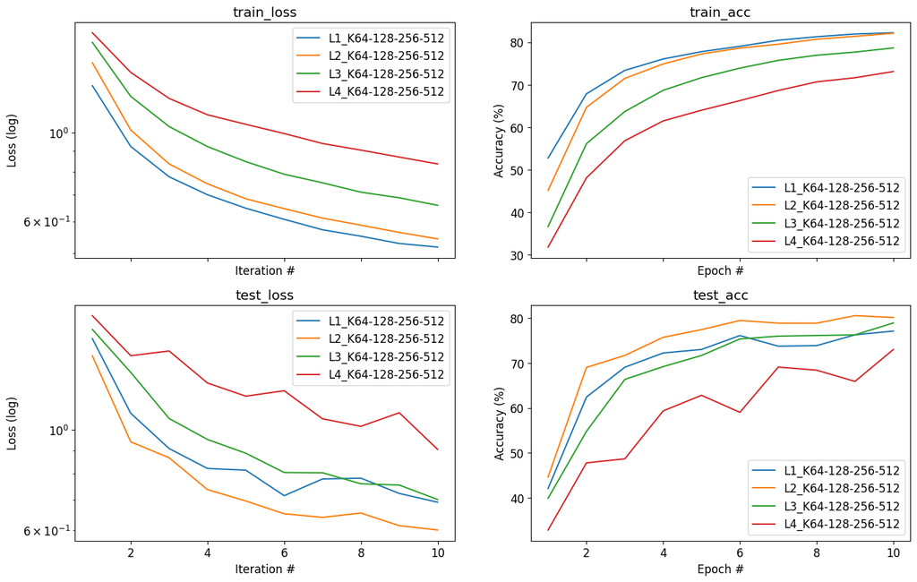

```python
plot_exp_results('exp2*.json')
```

## Questions

**TODO** Answer the following questions. Write your answers in the appropriate variables in the module `hw2/answers.py`.

```python
from helpers.answers import display_answer
import hw2.answers
```

### Question 1

Analyze your results from experiment 1.1. In particular,

1. Explain the effect of depth on the accuracy. What depth produces the best results and why do you think that's the case?
2. Were there values of `L` for which the network wasn't trainable? what causes this? Suggest two things which may be done to resolve it at least partially.

```python
display_answer(hw2.answers.part3_q1)
```

1. Setting L=2 leads to the highest accuracy for K=32 while setting L=4 leads to the highest accuracy for K=64. It seams that low L is the most suitable hyperparameter for this network since the training is stable and the loss is decreasing monotonically.

2. Setting L to 8/16 wasn't trainable - the accuracy was static (~10%) and the loss was high. As we learned in the course, it might happen due to vanishing gradients because the loss is very static. We can solve it by adding skip connections to the network.

### Question 2

Analyze your results from experiment 1.2. In particular, compare to the results of experiment 1.1.

```python
display_answer(hw2.answers.part3_q2)
```

For L=2, we can observe that K=64 achieves the best results with ~80% accuracy on the training set. For L=4, we can see the same but with K=128. As we saw in the previous experiment, for L=8/16 the net wasn't trainable.

### Question 3

Analyze your results from experiment 1.3.

```python
display_answer(hw2.answers.part3_q3)
```

We can observe that for this setting of filters, only L=1 an L=2 were trainable while L=4 wan't as opposed to previous experiments. Also L=2 results slightly higher accuracy than L=1 on the test set though the opposite on the training set. This means that the deeper network was less overfitted and generalizes better.

### Question 4

1. Explain your modifications to the architecture which you implemented in the `YourCodeNet` class.
2. Analyze the results of experiment 2. Compare to experiment 1.

```python
display_answer(hw2.answers.part3_q4)
```

In our custom network, we added:

We used hidden_dims=[512,512] and filters_per_layer=[64,128,256,512].

1. We were able to train the model with L>2, as opposed to the previous experiment.

# Running experiments on Colab

=

## 0. **IMPORTANT:** Make sure runtime uses GPU

**You will have to restart everything if you forget this.**

1. Go to "Runtime" > "change runtime type"
2. Select "GPU" for "Hardware accelerator"

## 1. Installation on Colab

Run the following commands to install the conda environment on Google Colab

```python
# Check python before conda installation (keep an eye on the version, should later change) many default packages are installed that we will later remove
# !python --version
# !pip list
```

```python
# Install conda (we will be using Mamba instead of anaconda/miniconda, but it shouldn't matter)
# Kernel should restart after this. Don't run the above cells again. Just keep going to the next cells
# !pip install -q condacolab
# import condacolab
# condacolab.install()
```

```python
# Check conda is installed
# import condacolab
# condacolab.check()

# !conda --version
```

```python
# Check python again (version should change slightly) should be only a few packages installed and conda should be listed
# !python --version
# !pip list
```

## 2. Set up conda environment

For this step, you need to upload environment.yml.

1. At the bar on the left (where "Table of Content" is shown), click on the file icon below.
2. Click on the "Upload to session storage" icon.
3. Locate the "environment.yml" file an upload it.
4. The file should be visible in the "Files" panel.
5. Run the below command.

```python
# !mamba env update -n base -f environment.yml
```

```python
# Check python for the last time (version should be 3.7.4 according to our file) all packages should be installed
# !python --version
# !pip list
```

## 3. Run experiments

1. Upload hw2 folder and helpers folder with their contents. (the same way you uploaded the environment.yml file.
2. Define the experiment you want to run.
3. Run the experiment.

Note: You can either use the console command or import run_experiments and run the cell. Select the one you prefer.

Note: When done, remember to download the json files in the "results" folder.

```python
# Run console command
# !python -m hw2.experiments run-exp -n "test_run" --seed 42 --bs-train 128 --epochs 10 --early-stopping 5 -K 32 -L 1 -P 1 -H 100
```

```python
# Run cell
# from hw2.experiments import run_experiment
# seed = 42
# run_experiment(
#     'test_run',
#     seed=seed,
#     bs_train=128,
#     epochs=10,
#     early_stopping=5,
#     filters_per_layer=[32],
#     layers_per_block=1,
#     pool_every=1,
#     hidden_dims=[100],
# )
```